# Rules and Interpretation: Statistical Results

GLMM analyses — condition effects, cross-experiment, SVO, Exp3 option tests

Bartosz Janik & Leo Hoeft

2026-03-26

# 1 Overview

This report presents **inferential statistical analyses** for all three experiments.

**Statistical approach:**

[output not shown]

**Reference condition:** `Normal` throughout (unless stated otherwise). **SVO:** Continuous angle (Murphy et al., 2011), z-scored in models.

# 2 SVO Distribution and Inequality Aversion (IA)

> **SVO Slider Measure (Murphy et al., 2011).** 6 *primary* items determine the SVO angle (°) and category assignment. Formula: SVO° = arctan((M_other − 50) / (M_self − 50)) × 180/π. Category thresholds: Competitive ≤ −12.04 < Individualistic ≤ 22.45 < Prosocial ≤ 57.15 < Altruistic.

> 9 *secondary* items are used to compute the **Inequality Aversion (IA) index** (Murphy et al., 2011). IA is a distance-based score (0 = pure Joint Gain orientation, 1 = pure Inequality Aversion). It is only defined for participants whose secondary-item pattern is best explained by IA or Joint Gain motivation (DIA ≤ DAL & DIA ≤ DIC & DJG ≤ DAL & DJG ≤ DIC); others receive NA. **IA is theoretically meaningful only for Prosocial individuals**, so all IA descriptives and the IA covariate GLMM are restricted to participants classified as Prosocial on the primary SVO items (angle > 22.45°). IA is used as a continuous covariate in a separate GLMM (see below).

> **Randomisation check:** Because this is a between-subjects design, SVO should be balanced across conditions. A Kruskal-Wallis test of SVO angle × Condition is reported below for each experiment. A non-significant result confirms that condition assignment did not produce systematic SVO differences.

## 2.1 Experiment 1 SVO

```
##
##
## Table: Exp1: Primary SVO angle — descriptive statistics (6 items)
##
## |   N|  Mean|    SD|    Min|   Max|
## |---:|-----:|-----:|------:|-----:|
## | 290| 23.12| 13.49| -16.26| 52.91|
```

```
##
##
## Table: Exp1: SVO category frequencies (6 primary items)
##
## |SVO_cat         |   N|  Pct|
## |:---------------|---:|----:|
## |Competitive     |   3|  1.0|
## |Individualistic | 126| 43.4|
## |Prosocial       | 161| 55.5|
```

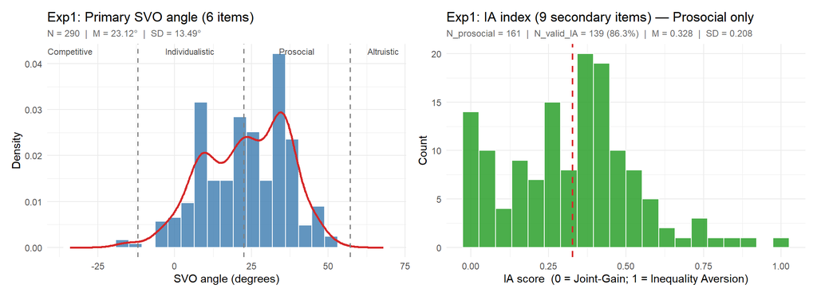

### 2.1.1 Exp1 — SVO by Condition (Randomisation Check)

```
## Exp1: Kruskal-Wallis SVO angle ~ Condition: χ²(5) = 2.51, p = 0.775  (balanced)
```

Exp1: Mean SVO angle (°) per condition — randomisation balance check

| Condition | N | Mean | SD |
| --- | --- | --- | --- |
| Normal | 11 | 24.02 | 12.61 |
| Over | 12 | 25.85 | 14.73 |
| Under | 1 | 37.48 | NA |
| OverUnder | 3 | 31.61 | 10.50 |
| UnderSelfish | 6 | 28.23 | 14.82 |
| OverUnderSelfish | 11 | 22.40 | 13.48 |

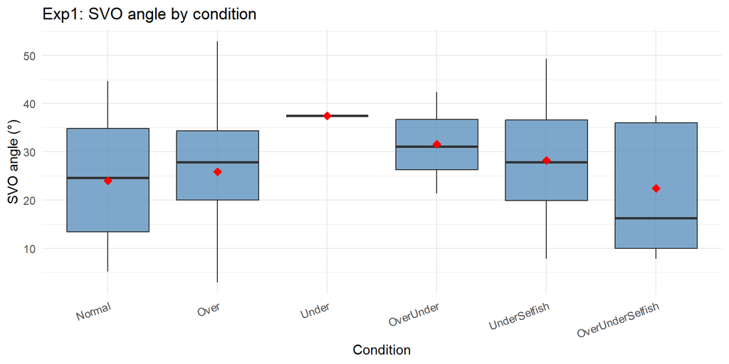

### 2.1.2 Exp1 — Inequality Aversion (IA) index

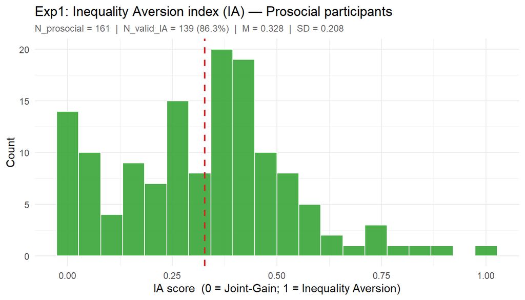

```
##
##
## Table: Exp1: IA index descriptives (Prosocial participants only)
##
## | N_prosocial| N_valid_IA| Pct_valid| Mean_IA| SD_IA| Min_IA| Max_IA|
## |-----------:|----------:|---------:|-------:|-----:|------:|------:|
## |         161|        139|      86.3|   0.328| 0.208|      0|      1|
```

```
##
##
## Table: Exp1: Dominant secondary motivation (Prosocial participants only)
##
## |dominant            |   N|  Pct|
## |:-------------------|---:|----:|
## |Individualism       |  12|  7.5|
## |Inequality Aversion | 118| 73.3|
## |Joint Gain          |  31| 19.3|
```

## 2.2 Experiment 2 SVO

```
##
##
## Table: Exp2: Primary SVO angle — descriptive statistics (6 items)
##
## |   N|  Mean|    SD|    Min|   Max|
## |---:|-----:|-----:|------:|-----:|
## | 302| 23.07| 13.65| -16.26| 61.39|
```

```
##
##
## Table: Exp2: SVO category frequencies (6 primary items)
##
## |SVO_cat         |   N|  Pct|
## |:---------------|---:|----:|
## |Competitive     |   2|  0.7|
## |Individualistic | 144| 47.7|
## |Prosocial       | 155| 51.3|
## |Altruistic      |   1|  0.3|
```

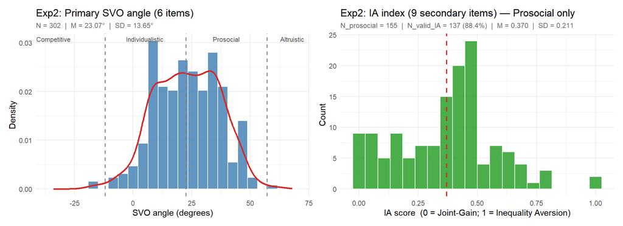

### 2.2.1 Exp2 — SVO by Condition (Randomisation Check)

[output not shown]

Exp2: Mean SVO angle (°) per condition — randomisation balance check

[output not shown]

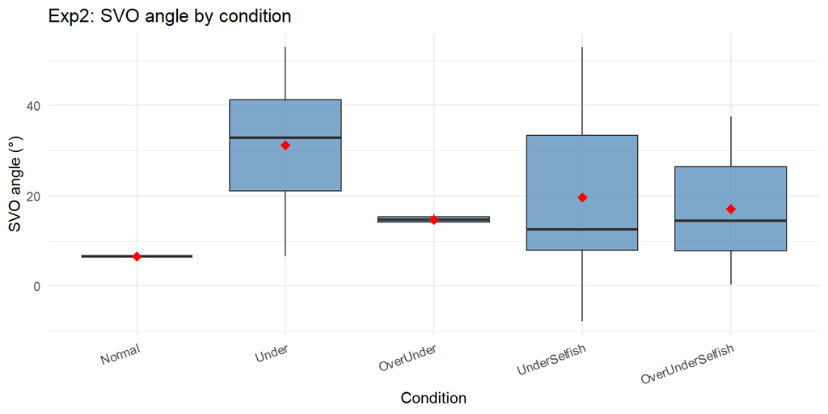

### 2.2.2 Exp2 — Inequality Aversion (IA) index

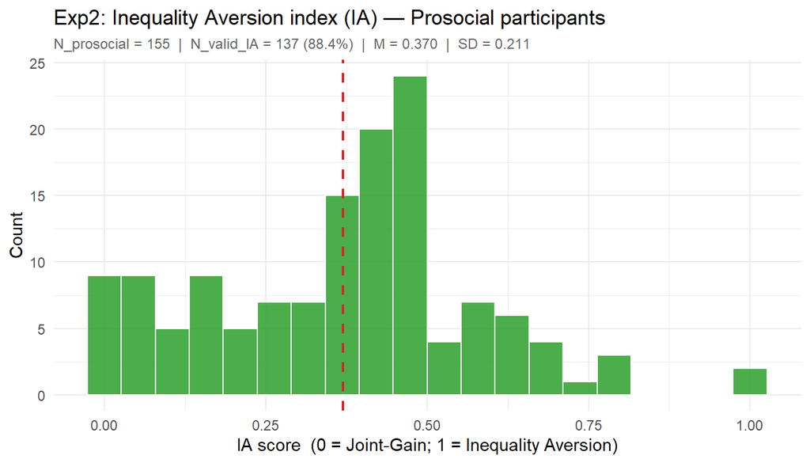

```
##
##
## Table: Exp2: IA index descriptives (Prosocial participants only)
##
## | N_prosocial| N_valid_IA| Pct_valid| Mean_IA| SD_IA| Min_IA| Max_IA|
## |-----------:|----------:|---------:|-------:|-----:|------:|------:|
## |         155|        137|      88.4|    0.37| 0.211|      0|      1|
```

```
##
##
## Table: Exp2: Dominant secondary motivation (Prosocial participants only)
##
## |dominant            |   N|  Pct|
## |:-------------------|---:|----:|
## |Altruism            |   1|  0.6|
## |Individualism       |   7|  4.5|
## |Inequality Aversion | 112| 72.3|
## |Joint Gain          |  35| 22.6|
```

## 2.3 Experiment 3 SVO

> Exp3 third-party evaluators completed the same SVO Slider Measure (Murphy et al., 2011). Primary items: Q3–Q8 (6 items, angle computation). Secondary items: Q9–Q17 (9 items, IA). Column Q2 is a constant demonstration item and is excluded.

```
##
##
## Table: Exp3: Primary SVO angle — descriptive statistics (Q3–Q8)
##
## |   N| Mean|    SD|   Min|   Max|
## |---:|----:|-----:|-----:|-----:|
## | 290| 28.3| 13.25| -7.82| 61.39|
```

```
##
##
## Table: Exp3: SVO category frequencies
##
## |SVO_cat         |   N|  Pct|
## |:---------------|---:|----:|
## |Individualistic |  86| 29.7|
## |Prosocial       | 203| 70.0|
## |Altruistic      |   1|  0.3|
```

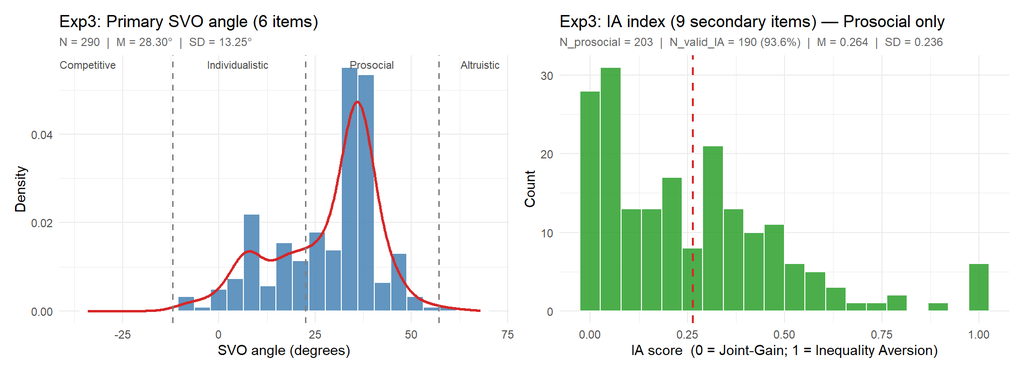

### 2.3.1 Exp3 — SVO by Condition (Randomisation Check)

```
## Exp3: Kruskal-Wallis SVO angle ~ Condition: χ²(3) = 1.80, p = 0.614  (balanced)
##
##
## Table: Exp3: Mean SVO angle (°) per condition
##
## |Condition        |   N|  Mean|    SD|
## |:----------------|---:|-----:|-----:|
## |Under            |  11| 27.49| 15.61|
## |OverUnder        |  42| 26.14| 13.55|
## |UnderSelfish     |  92| 28.88| 13.18|
## |OverUnderSelfish | 145| 28.63| 13.10|
```

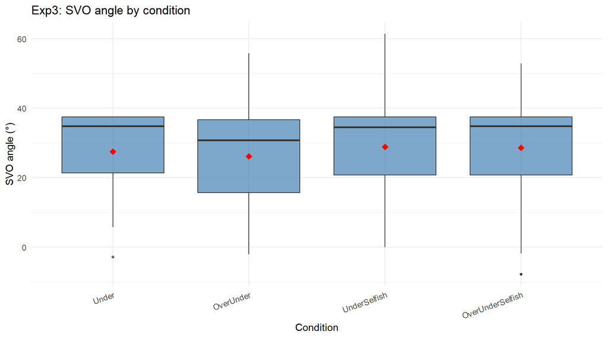

### 2.3.2 Exp3 — Inequality Aversion (IA) index

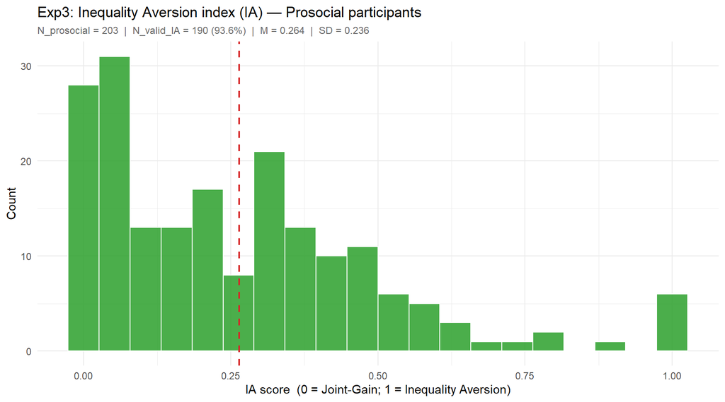

```
##
##
## Table: Exp3: IA index descriptives (Prosocial only)
##
## | N_prosocial| N_valid_IA| Pct_valid| Mean_IA| SD_IA| Min_IA| Max_IA|
## |-----------:|----------:|---------:|-------:|-----:|------:|------:|
## |         203|        190|      93.6|   0.264| 0.236|      0|      1|
```

```
##
##
## Table: Exp3: Dominant secondary motivation (Prosocial only)
##
## |dominant            |   N|  Pct|
## |:-------------------|---:|----:|
## |Individualism       |   6|  3.0|
## |Inequality Aversion | 166| 81.8|
## |Joint Gain          |  31| 15.3|
```

## 2.4 SVO Summary and Conclusions

SVO angle overview: all three experiments (Murphy et al., 2011, 6 primary items)

| Experiment | N | Mean | SD | Min | Max |
| --- | --- | --- | --- | --- | --- |
| Exp1 | 290 | 23.12 | 13.49 | -16.26 | 52.91 |
| Exp2 | 302 | 23.07 | 13.65 | -16.26 | 61.39 |
| Exp3 | 290 | 28.30 | 13.25 | -7.82 | 61.39 |

> **Summary of SVO findings:** All three samples consist predominantly of Individualists and Prosocials, consistent with Western online samples. SVO angle and IA index show no significant predictive relationship with rule adherence in Exp1 or Exp2 (all p > .13 in GLMM covariate models; see Parts 1–2 below). Exp3 SVO is reported descriptively; the Kruskal-Wallis balance tests confirm that condition assignment is not confounded with SVO in any experiment. This null pattern holds for the continuous angle, the Prosocial/Individualistic classification, and the IA sub-index (Prosocial subset only). Rule interpretation under text–purpose divergence appears to be a cognitive/contextual process that operates independently of prosocial motivation.

# 3 Part 1: Condition Effects — Experiment 1 (Coordination)

## 3.1 Descriptive summary

Exp1: N, N chose E, % adherence by condition

| Condition | N | N_E | Pct_E |
| --- | --- | --- | --- |
| Normal | 97 | 86 | 88.7 |
| Over | 96 | 82 | 85.4 |
| Under | 97 | 64 | 66.0 |
| OverUnder | 97 | 62 | 63.9 |
| UnderSelfish | 97 | 82 | 84.5 |
| OverUnderSelfish | 96 | 76 | 79.2 |

## 3.2 Simple tests: pairwise proportion tests (χ²)

Exp1: Pairwise χ² tests of adherence proportions (Bonferroni)

|  | Cond1 | Cond2 | N1 | Pct1 | N2 | Pct2 | Chi_sq | df | p_raw | test | p_adj | sig |
| --- | --- | --- | --- | --- | --- | --- | --- | --- | --- | --- | --- | --- |
| X-squared…1 | Normal | Over | 97 | 88.7 | 96 | 85.4 | 0.450 | 1 | 0.5023 | chisq | 1.0000 |  |
| X-squared…2 | Normal | Under | 97 | 88.7 | 97 | 66.0 | 14.227 | 1 | 0.0002 | chisq | 0.0030 | ** |
| X-squared…3 | Normal | OverUnder | 97 | 88.7 | 97 | 63.9 | 16.414 | 1 | 0.0001 | chisq | 0.0015 | ** |
| X-squared…4 | Normal | UnderSelfish | 97 | 88.7 | 97 | 84.5 | 0.711 | 1 | 0.3992 | chisq | 1.0000 |  |
| X-squared…5 | Normal | OverUnderSelfish | 97 | 88.7 | 96 | 79.2 | 3.225 | 1 | 0.0725 | chisq | 1.0000 |  |
| X-squared…6 | Over | Under | 96 | 85.4 | 97 | 66.0 | 9.895 | 1 | 0.0017 | chisq | 0.0255 | * |
| X-squared…7 | Over | OverUnder | 96 | 85.4 | 97 | 63.9 | 11.773 | 1 | 0.0006 | chisq | 0.0090 | ** |
| X-squared…8 | Over | UnderSelfish | 96 | 85.4 | 97 | 84.5 | 0.029 | 1 | 0.8641 | chisq | 1.0000 |  |
| X-squared…9 | Over | OverUnderSelfish | 96 | 85.4 | 96 | 79.2 | 1.287 | 1 | 0.2567 | chisq | 1.0000 |  |
| X-squared…10 | Under | OverUnder | 97 | 66.0 | 97 | 63.9 | 0.091 | 1 | 0.7635 | chisq | 1.0000 |  |
| X-squared…11 | Under | UnderSelfish | 97 | 66.0 | 97 | 84.5 | 8.969 | 1 | 0.0027 | chisq | 0.0405 | * |
| X-squared…12 | Under | OverUnderSelfish | 97 | 66.0 | 96 | 79.2 | 4.212 | 1 | 0.0401 | chisq | 0.6015 |  |
| X-squared…13 | OverUnder | UnderSelfish | 97 | 63.9 | 97 | 84.5 | 10.778 | 1 | 0.0010 | chisq | 0.0150 | * |
| X-squared…14 | OverUnder | OverUnderSelfish | 97 | 63.9 | 96 | 79.2 | 5.506 | 1 | 0.0189 | chisq | 0.2835 |  |
| X-squared…15 | UnderSelfish | OverUnderSelfish | 97 | 84.5 | 96 | 79.2 | 0.937 | 1 | 0.3331 | chisq | 1.0000 |  |

## 3.3 GLMM: Condition only

Exp1 base GLMM — likelihood-ratio test for Condition

| Term | Chi_sq | df | p | sig |
| --- | --- | --- | --- | --- |
| Condition | 36.2745 | 5 | 0 | *** |

Exp1 base GLMM — fixed effects (OR, 95% CI)

| effect | term | OR | std.error | statistic | p.value | 2.5% | 97.5% | sig |
| --- | --- | --- | --- | --- | --- | --- | --- | --- |
| fixed | (Intercept) | 1.457066e+08 | 3.640816e+08 | 7.522660 | 0.0000 | 1087815.502 | 1.951655e+10 | *** |
| fixed | ConditionOver | 1.280000e-01 | 2.183185e-01 | -1.204553 | 0.2284 | 0.004 | 3.633000e+00 |  |
| fixed | ConditionUnder | 0.000000e+00 | 7.960000e-05 | -4.892552 | 0.0000 | 0.000 | 2.000000e-03 | *** |
| fixed | ConditionOverUnder | 0.000000e+00 | 8.240000e-05 | -5.164444 | 0.0000 | 0.000 | 2.000000e-03 | *** |
| fixed | ConditionUnderSelfish | 4.700000e-02 | 8.144980e-02 | -1.761288 | 0.0782 | 0.002 | 1.412000e+00 | . |
| fixed | ConditionOverUnderSelfish | 3.700000e-02 | 6.439450e-02 | -1.909132 | 0.0562 | 0.001 | 1.091000e+00 | . |

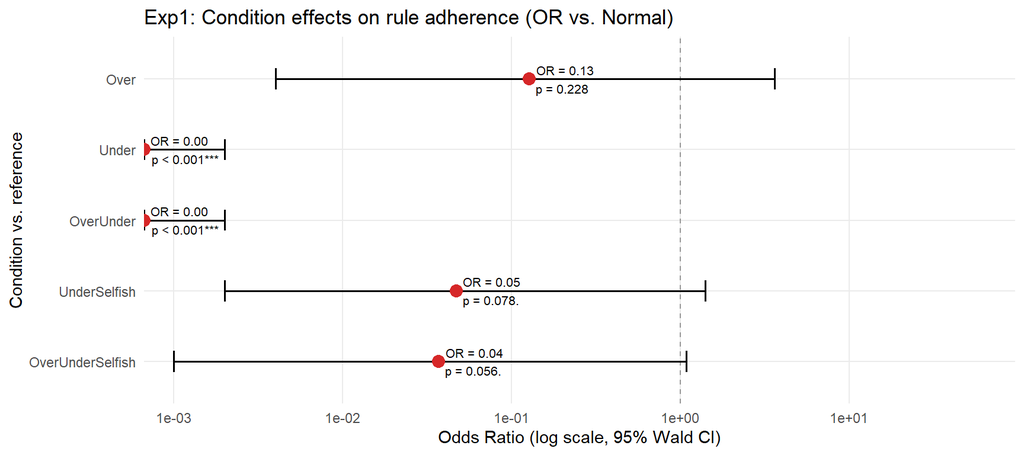

### 3.3.1 Separation check

```
## ⚠️  Quasi-complete separation detected in Exp1 base GLMM.
##    Max |fixed-effect coef| = 18.8
##    Estimated marginal probabilities and ORs below should be interpreted
##    with caution. See 'Robust model' subsection for regularized estimates.
```

### 3.3.2 Estimated marginal probabilities

Exp1: Estimated P(chose E) per condition (95% CI)

| Condition | prob | SE | lower.CL | upper.CL |
| --- | --- | --- | --- | --- |
| Normal | 1 | 0 | 1.000 | 1 |
| Over | 1 | 0 | 1.000 | 1 |
| Under | 1 | 0 | 0.999 | 1 |
| OverUnder | 1 | 0 | 0.999 | 1 |
| UnderSelfish | 1 | 0 | 1.000 | 1 |
| OverUnderSelfish | 1 | 0 | 1.000 | 1 |

### 3.3.3 Pairwise contrasts (Bonferroni)

Exp1: All pairwise ORs (Bonferroni-corrected)

| contrast | OR | SE | z.ratio | df | p.value | sig |
| --- | --- | --- | --- | --- | --- | --- |
| Normal - Over | 7.822 | 1.7075900 | 1.2045533 | Inf | 1.0000 |  |
| Normal - Under | 26106.672 | 2.0786588 | 4.8925519 | Inf | 0.0000 | *** |
| Normal - OverUnder | 23660.452 | 1.9501730 | 5.1644444 | Inf | 0.0000 | *** |
| Normal - UnderSelfish | 21.332 | 1.7374816 | 1.7612879 | Inf | 1.0000 |  |
| Normal - OverUnderSelfish | 26.726 | 1.7210122 | 1.9091325 | Inf | 0.8437 |  |
| Over - Under | 3337.786 | 1.6417323 | 4.9417699 | Inf | 0.0000 | *** |
| Over - OverUnder | 3025.032 | 1.5344631 | 5.2231151 | Inf | 0.0000 | *** |
| Over - UnderSelfish | 2.727 | 1.7487448 | 0.5737384 | Inf | 1.0000 |  |
| Over - OverUnderSelfish | 3.417 | 1.2976452 | 0.9469132 | Inf | 1.0000 |  |
| Under - OverUnder | 0.906 | 0.9013994 | -0.1091481 | Inf | 1.0000 |  |
| Under - UnderSelfish | 0.001 | 2.1522515 | -3.3033969 | Inf | 0.0143 | * |
| Under - OverUnderSelfish | 0.001 | 1.7747576 | -3.8790119 | Inf | 0.0016 | ** |
| OverUnder - UnderSelfish | 0.001 | 2.0033256 | -3.4998579 | Inf | 0.0070 | ** |
| OverUnder - OverUnderSelfish | 0.001 | 1.6676469 | -4.0691586 | Inf | 0.0007 | *** |
| UnderSelfish - OverUnderSelfish | 1.253 | 1.7627836 | 0.1278859 | Inf | 1.0000 |  |

### 3.3.4 Model fit

Exp1 base GLMM — ICC and pseudo-R²

| ICC | R2_marginal.Marginal R2 | R2_conditional.Conditional R2 |
| --- | --- | --- |
| 0.964 | 0.03 | 0.994 |

### 3.3.5 Robust model (blme — Bayesian penalization, if separation detected)

> Refit with weakly informative normal priors (SD = 3 on log-OR scale; Chung et al., 2013). This regularizes inflated estimates without changing the model structure. The LRT p-value from the standard GLMM remains the primary test of the condition effect.

```
## Exp1 robust GLMM (blme, prior SD = 3) — fixed effects:
##
##
##
## Table: Exp1 robust GLMM — ORs (blme)
##
## |effect |term                      |        OR|    std.error|  statistic| p.value|     2.5%|      97.5%|sig |
## |:------|:-------------------------|---------:|------------:|----------:|-------:|--------:|----------:|:---|
## |fixed  |(Intercept)               | 31867.522| 4.071086e+04|  8.1168825|  0.0000| 2605.768| 389727.377|*** |
## |fixed  |ConditionOver             |     2.129| 2.587826e+00|  0.6213718|  0.5344|    0.196|     23.065|    |
## |fixed  |ConditionUnder            |     0.027| 2.804800e-02| -3.4629757|  0.0005|    0.003|      0.208|*** |
## |fixed  |ConditionOverUnder        |     0.020| 2.031820e-02| -3.8789400|  0.0001|    0.003|      0.145|*** |
## |fixed  |ConditionUnderSelfish     |     0.448| 4.845221e-01| -0.7426307|  0.4577|    0.054|      3.736|    |
## |fixed  |ConditionOverUnderSelfish |     0.629| 6.910215e-01| -0.4223211|  0.6728|    0.073|      5.421|    |
##
## Estimated marginal probabilities (regularized):
##
##
##
## Table: Exp1 robust GLMM — P(chose E)
##
## |Condition        |  prob|    SE| lower.CL| upper.CL|
## |:----------------|-----:|-----:|--------:|--------:|
## |Normal           | 1.000| 0.000|    1.000|        1|
## |Over             | 1.000| 0.000|    1.000|        1|
## |Under            | 0.999| 0.001|    0.994|        1|
## |OverUnder        | 0.998| 0.001|    0.992|        1|
## |UnderSelfish     | 1.000| 0.000|    0.999|        1|
## |OverUnderSelfish | 1.000| 0.000|    0.999|        1|
```

## 3.4 GLMM: Condition + SVO (additive)

Exp1 +SVO GLMM — likelihood-ratio tests

| Term | Chi_sq | df | p | sig |
| --- | --- | --- | --- | --- |
| Condition | 35.8731 | 5 | 0.0000 | *** |
| scale(SVO_all) | 0.0518 | 1 | 0.8199 |  |

Exp1 +SVO GLMM — fixed effects (OR, 95% CI)

| effect | term | OR | std.error | statistic | p.value | 2.5% | 97.5% | sig |
| --- | --- | --- | --- | --- | --- | --- | --- | --- |
| fixed | (Intercept) | 1.445943e+08 | 3.633284e+08 | 7.4776630 | 0.0000 | 1050269.850 | 1.990681e+10 | *** |
| fixed | ConditionOver | 1.280000e-01 | 2.179272e-01 | -1.2056284 | 0.2280 | 0.004 | 3.626000e+00 |  |
| fixed | ConditionUnder | 0.000000e+00 | 7.940000e-05 | -4.8772804 | 0.0000 | 0.000 | 2.000000e-03 | *** |
| fixed | ConditionOverUnder | 0.000000e+00 | 8.340000e-05 | -5.1410754 | 0.0000 | 0.000 | 2.000000e-03 | *** |
| fixed | ConditionUnderSelfish | 4.700000e-02 | 8.175560e-02 | -1.7592063 | 0.0785 | 0.002 | 1.417000e+00 | . |
| fixed | ConditionOverUnderSelfish | 3.700000e-02 | 6.434820e-02 | -1.9096780 | 0.0562 | 0.001 | 1.090000e+00 | . |
| fixed | scale(SVO_all) | 8.800000e-01 | 4.940620e-01 | -0.2276456 | 0.8199 | 0.293 | 2.645000e+00 |  |

## 3.5 GLMM: Condition × SVO (interaction)

> Tests whether the effect of SVO on adherence differs across conditions.

Exp1 ×SVO GLMM — likelihood-ratio tests (interaction model)

| Term | Chi_sq | df | p | sig |
| --- | --- | --- | --- | --- |
| Condition | 34.6023 | 5 | 0.0000 | *** |
| scale(SVO_all) | 0.0398 | 1 | 0.8419 |  |
| Condition:scale(SVO_all) | 7.5097 | 5 | 0.1854 |  |

Exp1 ×SVO GLMM — fixed effects (OR, 95% CI)

| effect | term | OR | std.error | statistic | p.value | 2.5% | 97.5% | sig |
| --- | --- | --- | --- | --- | --- | --- | --- | --- |
| fixed | (Intercept) | 3.054965e+08 | 7.836003e+08 | 7.6169217 | 0.0000 | 2002946.110 | 4.659542e+10 | *** |
| fixed | ConditionOver | 5.500000e-02 | 1.035221e-01 | -1.5359487 | 0.1246 | 0.001 | 2.230000e+00 |  |
| fixed | ConditionUnder | 0.000000e+00 | 4.890000e-05 | -4.9519180 | 0.0000 | 0.000 | 2.000000e-03 | *** |
| fixed | ConditionOverUnder | 0.000000e+00 | 4.970000e-05 | -5.1750611 | 0.0000 | 0.000 | 1.000000e-03 | *** |
| fixed | ConditionUnderSelfish | 5.600000e-02 | 1.005977e-01 | -1.5978857 | 0.1101 | 0.002 | 1.924000e+00 |  |
| fixed | ConditionOverUnderSelfish | 2.400000e-02 | 4.315410e-02 | -2.0661734 | 0.0388 | 0.001 | 8.250000e-01 | * |
| fixed | scale(SVO_all) | 7.560000e-01 | 1.269492e+00 | -0.1663826 | 0.8679 | 0.028 | 2.029700e+01 |  |
| fixed | ConditionOver:scale(SVO_all) | 3.967000e+00 | 7.976707e+00 | 0.6853898 | 0.4931 | 0.077 | 2.041500e+02 |  |
| fixed | ConditionUnder:scale(SVO_all) | 1.486000e+00 | 2.494823e+00 | 0.2358804 | 0.8135 | 0.055 | 3.991500e+01 |  |
| fixed | ConditionOverUnder:scale(SVO_all) | 8.990000e-01 | 1.511592e+00 | -0.0634279 | 0.9494 | 0.033 | 2.427600e+01 |  |
| fixed | ConditionUnderSelfish:scale(SVO_all) | 4.130000e-01 | 8.322341e-01 | -0.4388110 | 0.6608 | 0.008 | 2.140500e+01 |  |
| fixed | ConditionOverUnderSelfish:scale(SVO_all) | 7.300000e-02 | 1.408437e-01 | -1.3607572 | 0.1736 | 0.002 | 3.159000e+00 |  |

## 3.6 GLMM: Condition + IA (Inequality Aversion)

> **IA (Inequality Aversion index)** is computed from the 9 secondary SVO items (Murphy et al., 2011). It ranges from 0 (Joint Gain) to 1 (Inequality Aversion). **Analysis restricted to Prosocial participants** (primary SVO angle > 22.45°) with a valid (non-NA) IA score. IA is z-scored in the model.

```
## N Prosocial with valid IA (Exp1): 139 of 161 Prosocial participants
```

Exp1 +IA GLMM — fixed effects (OR, 95% CI)

| effect | term | OR | std.error | statistic | p.value | 2.5% | 97.5% | sig |
| --- | --- | --- | --- | --- | --- | --- | --- | --- |
| fixed | (Intercept) | 20725472.398 | 6.490406e+07 | 5.3796235 | 0.0000 | 44758.401 | 9.596974e+09 | *** |
| fixed | ConditionOver | 0.927 | 2.280145e+00 | -0.0308726 | 0.9754 | 0.007 | 1.150870e+02 |  |
| fixed | ConditionUnder | 0.000 | 4.241000e-04 | -3.3535701 | 0.0008 | 0.000 | 2.700000e-02 | *** |
| fixed | ConditionOverUnder | 0.000 | 3.031000e-04 | -3.6170723 | 0.0003 | 0.000 | 1.600000e-02 | *** |
| fixed | ConditionUnderSelfish | 0.012 | 2.956820e-02 | -1.8351505 | 0.0665 | 0.000 | 1.348000e+00 | . |
| fixed | ConditionOverUnderSelfish | 0.002 | 3.997100e-03 | -2.6019129 | 0.0093 | 0.000 | 2.050000e-01 | ** |
| fixed | scale(IA) | 0.537 | 4.569196e-01 | -0.7309115 | 0.4648 | 0.101 | 2.847000e+00 |  |

# 4 Part 2: Condition Effects — Experiment 2 DG (Anticipated Punishment)

## 4.1 Descriptive summary

Exp2 DG: adherence by condition

| Condition | N | N_E | Pct_E |
| --- | --- | --- | --- |
| Normal | 101 | 97 | 96.0 |
| Over | 101 | 96 | 95.0 |
| Under | 101 | 83 | 82.2 |
| OverUnder | 100 | 77 | 77.0 |
| UnderSelfish | 100 | 91 | 91.0 |
| OverUnderSelfish | 101 | 80 | 79.2 |

## 4.2 Simple tests: pairwise proportion tests (χ²)

Exp2 DG: Pairwise χ² tests of adherence proportions (Bonferroni)

|  | Cond1 | Cond2 | N1 | Pct1 | N2 | Pct2 | Chi_sq | df | p_raw | test | p_adj | sig |
| --- | --- | --- | --- | --- | --- | --- | --- | --- | --- | --- | --- | --- |
| …1 | Normal | Over | 101 | 96.0 | 101 | 95.0 | NA | NA | 1.0000 | fisher | 1.0000 |  |
| X-squared…2 | Normal | Under | 101 | 96.0 | 101 | 82.2 | 9.998 | 1 | 0.0016 | chisq | 0.0240 | * |
| X-squared…3 | Normal | OverUnder | 101 | 96.0 | 100 | 77.0 | 15.665 | 1 | 0.0001 | chisq | 0.0015 | ** |
| X-squared…4 | Normal | UnderSelfish | 101 | 96.0 | 100 | 91.0 | 2.110 | 1 | 0.1464 | chisq | 1.0000 |  |
| X-squared…5 | Normal | OverUnderSelfish | 101 | 96.0 | 101 | 79.2 | 13.193 | 1 | 0.0003 | chisq | 0.0045 | ** |
| X-squared…6 | Over | Under | 101 | 95.0 | 101 | 82.2 | 8.292 | 1 | 0.0040 | chisq | 0.0600 | . |
| X-squared…7 | Over | OverUnder | 101 | 95.0 | 100 | 77.0 | 13.653 | 1 | 0.0002 | chisq | 0.0030 | ** |
| X-squared…8 | Over | UnderSelfish | 101 | 95.0 | 100 | 91.0 | 1.272 | 1 | 0.2595 | chisq | 1.0000 |  |
| X-squared…9 | Over | OverUnderSelfish | 101 | 95.0 | 101 | 79.2 | 11.301 | 1 | 0.0008 | chisq | 0.0120 | * |
| X-squared…10 | Under | OverUnder | 101 | 82.2 | 100 | 77.0 | 0.830 | 1 | 0.3623 | chisq | 1.0000 |  |
| X-squared…11 | Under | UnderSelfish | 101 | 82.2 | 100 | 91.0 | 3.363 | 1 | 0.0667 | chisq | 1.0000 |  |
| X-squared…12 | Under | OverUnderSelfish | 101 | 82.2 | 101 | 79.2 | 0.286 | 1 | 0.5928 | chisq | 1.0000 |  |
| X-squared…13 | OverUnder | UnderSelfish | 100 | 77.0 | 100 | 91.0 | 7.292 | 1 | 0.0069 | chisq | 0.1035 |  |
| X-squared…14 | OverUnder | OverUnderSelfish | 100 | 77.0 | 101 | 79.2 | 0.143 | 1 | 0.7051 | chisq | 1.0000 |  |
| X-squared…15 | UnderSelfish | OverUnderSelfish | 100 | 91.0 | 101 | 79.2 | 5.503 | 1 | 0.0190 | chisq | 0.2850 |  |

## 4.3 GLMM: Condition only

Exp2 DG base GLMM — LRT for Condition

| Term | Chi_sq | df | p | sig |
| --- | --- | --- | --- | --- |
| Condition | 30.9099 | 5 | 0 | *** |

Exp2 DG base GLMM — fixed effects

| effect | term | OR | std.error | statistic | p.value | 2.5% | 97.5% | sig |
| --- | --- | --- | --- | --- | --- | --- | --- | --- |
| fixed | (Intercept) | 191951.282 | 5.682942e+05 | 4.1089398 | 0.0000 | 579.575 | 63573005.710 | *** |
| fixed | ConditionOver | 0.094 | 2.542160e-01 | -0.8762969 | 0.3809 | 0.000 | 18.524 |  |
| fixed | ConditionUnder | 0.048 | 1.384415e-01 | -1.0485601 | 0.2944 | 0.000 | 14.078 |  |
| fixed | ConditionOverUnder | 0.014 | 3.952650e-02 | -1.4949024 | 0.1349 | 0.000 | 3.791 |  |
| fixed | ConditionUnderSelfish | 8.370 | 2.462172e+01 | 0.7222272 | 0.4702 | 0.026 | 2671.424 |  |
| fixed | ConditionOverUnderSelfish | 0.021 | 5.996200e-02 | -1.3451799 | 0.1786 | 0.000 | 5.866 |  |

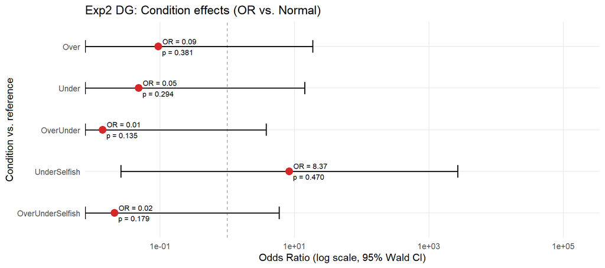

```
## ⚠️  Quasi-complete separation detected in Exp2 DG base GLMM.
##    Max |fixed-effect coef| = 12.2
##    EMMs and ORs below may be unreliable. See robust model subsection.
```

Exp2 DG: Estimated P(chose E) per condition

| Condition | prob | SE | lower.CL | upper.CL |
| --- | --- | --- | --- | --- |
| Normal | 1 | 0 | 0.998 | 1 |
| Over | 1 | 0 | 0.999 | 1 |
| Under | 1 | 0 | 0.999 | 1 |
| OverUnder | 1 | 0 | 0.997 | 1 |
| UnderSelfish | 1 | 0 | 1.000 | 1 |
| OverUnderSelfish | 1 | 0 | 0.998 | 1 |

Exp2 DG: Pairwise ORs (Bonferroni)

| contrast | OR | SE | z.ratio | df | p.value | sig |
| --- | --- | --- | --- | --- | --- | --- |
| Normal - Over | 10.596 | 2.6937109 | 0.8762969 | Inf | 1.0000 |  |
| Normal - Under | 20.960 | 2.9016961 | 1.0485601 | Inf | 1.0000 |  |
| Normal - OverUnder | 72.493 | 2.8653991 | 1.4949024 | Inf | 1.0000 |  |
| Normal - UnderSelfish | 0.119 | 2.9417615 | -0.7222272 | Inf | 1.0000 |  |
| Normal - OverUnderSelfish | 47.992 | 2.8777118 | 1.3451799 | Inf | 1.0000 |  |
| Over - Under | 1.978 | 1.7075681 | 0.3994640 | Inf | 1.0000 |  |
| Over - OverUnder | 6.841 | 1.6136928 | 1.1916775 | Inf | 1.0000 |  |
| Over - UnderSelfish | 0.011 | 1.9863946 | -2.2579154 | Inf | 0.3593 |  |
| Over - OverUnderSelfish | 4.529 | 1.6401081 | 0.9210060 | Inf | 1.0000 |  |
| Under - OverUnder | 3.459 | 1.1762856 | 1.0549219 | Inf | 1.0000 |  |
| Under - UnderSelfish | 0.006 | 1.5765718 | -3.2775056 | Inf | 0.0157 | * |
| Under - OverUnderSelfish | 2.290 | 0.7620006 | 1.0871874 | Inf | 1.0000 |  |
| OverUnder - UnderSelfish | 0.002 | 1.1909688 | -5.3805880 | Inf | 0.0000 | *** |
| OverUnder - OverUnderSelfish | 0.662 | 1.0812370 | -0.3814630 | Inf | 1.0000 |  |
| UnderSelfish - OverUnderSelfish | 401.682 | 1.5418952 | 3.8885007 | Inf | 0.0015 | ** |

### 4.3.1 Robust model (blme, if separation detected)

```
## Exp2 DG robust GLMM (blme, prior SD = 3) — fixed effects:
##
##
##
## Table: Exp2 DG robust GLMM — ORs (blme)
##
## |effect |term                      |       OR|    std.error|  statistic| p.value|     2.5%|     97.5%|sig |
## |:------|:-------------------------|--------:|------------:|----------:|-------:|--------:|---------:|:---|
## |fixed  |(Intercept)               | 8516.134| 8490.8399552|  9.0766765|  0.0000| 1206.616| 60105.727|*** |
## |fixed  |ConditionOver             |    0.939|    1.1107928| -0.0529764|  0.9578|    0.093|     9.537|    |
## |fixed  |ConditionUnder            |    0.711|    0.8074555| -0.3004358|  0.7638|    0.077|     6.586|    |
## |fixed  |ConditionOverUnder        |    0.187|    0.1913062| -1.6401752|  0.1010|    0.025|     1.386|    |
## |fixed  |ConditionUnderSelfish     |   48.172|   68.7485018|  2.7150696|  0.0066|    2.938|   789.915|**  |
## |fixed  |ConditionOverUnderSelfish |    0.329|    0.3506099| -1.0431482|  0.2969|    0.041|     2.657|    |
##
## Estimated marginal probabilities (regularized):
##
##
##
## Table: Exp2 DG robust GLMM — P(chose E)
##
## |Condition        |  prob|    SE| lower.CL| upper.CL|
## |:----------------|-----:|-----:|--------:|--------:|
## |Normal           | 1.000| 0.000|    0.999|        1|
## |Over             | 1.000| 0.000|    0.999|        1|
## |Under            | 1.000| 0.000|    0.999|        1|
## |OverUnder        | 0.999| 0.001|    0.997|        1|
## |UnderSelfish     | 1.000| 0.000|    1.000|        1|
## |OverUnderSelfish | 1.000| 0.000|    0.998|        1|
```

## 4.4 GLMM: Condition + SVO

Exp2 DG +SVO — LRT

| Term | Chi_sq | df | p | sig |
| --- | --- | --- | --- | --- |
| Condition | 30.8155 | 5 | 0.0000 | *** |
| scale(SVO_all) | 0.0001 | 1 | 0.9931 |  |

Exp2 DG +SVO — fixed effects

| effect | term | OR | std.error | statistic | p.value | 2.5% | 97.5% | sig |
| --- | --- | --- | --- | --- | --- | --- | --- | --- |
| fixed | (Intercept) | 191896.970 | 5.712475e+05 | 4.0864455 | 0.0000 | 561.272 | 65608931.229 | *** |
| fixed | ConditionOver | 0.094 | 2.553362e-01 | -0.8725767 | 0.3829 | 0.000 | 18.940 |  |
| fixed | ConditionUnder | 0.048 | 1.391274e-01 | -1.0435596 | 0.2967 | 0.000 | 14.464 |  |
| fixed | ConditionOverUnder | 0.014 | 3.972870e-02 | -1.4875866 | 0.1369 | 0.000 | 3.897 |  |
| fixed | ConditionUnderSelfish | 8.370 | 2.471591e+01 | 0.7195317 | 0.4718 | 0.026 | 2730.301 |  |
| fixed | ConditionOverUnderSelfish | 0.021 | 6.026790e-02 | -1.3385812 | 0.1807 | 0.000 | 6.031 |  |
| fixed | scale(SVO_all) | 0.996 | 4.852174e-01 | -0.0086964 | 0.9931 | 0.383 | 2.588 |  |

## 4.5 GLMM: Condition + IA (Inequality Aversion)

> Same model structure as Exp1: `Rule_Adherence ~ Condition + scale(IA) + (1|ResponseId)`. **Restricted to Prosocial participants** (primary SVO angle > 22.45°) with valid IA.

```
## N Prosocial with valid IA (Exp2 DG): 137 of 155 Prosocial participants
```

Exp2 DG +IA GLMM — fixed effects (OR, 95% CI)

| effect | term | OR | std.error | statistic | p.value | 2.5% | 97.5% | sig |
| --- | --- | --- | --- | --- | --- | --- | --- | --- |
| fixed | (Intercept) | 211960.686 | 1.025788e+06 | 2.5341681 | 0.0113 | 16.101 | 2.790370e+09 | * |
| fixed | ConditionOver | 1.000 | 5.795761e+00 | -0.0000043 | 1.0000 | 0.000 | 8.579718e+04 |  |
| fixed | ConditionUnder | 9.862 | 5.299693e+01 | 0.4259069 | 0.6702 | 0.000 | 3.699187e+05 |  |
| fixed | ConditionOverUnder | 0.052 | 2.566924e-01 | -0.5997915 | 0.5486 | 0.000 | 8.121070e+02 |  |
| fixed | ConditionUnderSelfish | 1655.429 | 9.438887e+03 | 1.2999136 | 0.1936 | 0.023 | 1.181057e+08 |  |
| fixed | ConditionOverUnderSelfish | 0.050 | 2.473390e-01 | -0.6066575 | 0.5441 | 0.000 | 7.938310e+02 |  |
| fixed | scale(IA) | 0.734 | 7.336578e-01 | -0.3092764 | 0.7571 | 0.104 | 5.205000e+00 |  |

# 5 Part 3: Condition Effects — Experiment 2 BT (Belief Task)

> **DV:** Believed others chose option E (1/0). Measures normative beliefs, not own behavior.

## 5.1 Descriptive summary

Exp2 BT: belief about E by condition

| Condition | N | N_E | Pct_E |
| --- | --- | --- | --- |
| Normal | 100 | 90 | 90.0 |
| Over | 100 | 89 | 89.0 |
| Under | 101 | 61 | 60.4 |
| OverUnder | 101 | 60 | 59.4 |
| UnderSelfish | 101 | 74 | 73.3 |
| OverUnderSelfish | 101 | 65 | 64.4 |

## 5.2 Simple tests: pairwise proportion tests (χ²)

Exp2 BT: Pairwise χ² tests of belief proportions (Bonferroni)

|  | Cond1 | Cond2 | N1 | Pct1 | N2 | Pct2 | Chi_sq | df | p_raw | test | p_adj | sig |
| --- | --- | --- | --- | --- | --- | --- | --- | --- | --- | --- | --- | --- |
| X-squared…1 | Normal | Over | 100 | 90.0 | 100 | 89.0 | 0.053 | 1 | 0.8176 | chisq | 1.0000 |  |
| X-squared…2 | Normal | Under | 100 | 90.0 | 101 | 60.4 | 23.565 | 1 | 0.0000 | chisq | 0.0000 | *** |
| X-squared…3 | Normal | OverUnder | 100 | 90.0 | 101 | 59.4 | 24.839 | 1 | 0.0000 | chisq | 0.0000 | *** |
| X-squared…4 | Normal | UnderSelfish | 100 | 90.0 | 101 | 73.3 | 9.367 | 1 | 0.0022 | chisq | 0.0330 | * |
| X-squared…5 | Normal | OverUnderSelfish | 100 | 90.0 | 101 | 64.4 | 18.723 | 1 | 0.0000 | chisq | 0.0000 | *** |
| X-squared…6 | Over | Under | 100 | 89.0 | 101 | 60.4 | 21.712 | 1 | 0.0000 | chisq | 0.0000 | *** |
| X-squared…7 | Over | OverUnder | 100 | 89.0 | 101 | 59.4 | 22.948 | 1 | 0.0000 | chisq | 0.0000 | *** |
| X-squared…8 | Over | UnderSelfish | 100 | 89.0 | 101 | 73.3 | 8.112 | 1 | 0.0044 | chisq | 0.0660 | . |
| X-squared…9 | Over | OverUnderSelfish | 100 | 89.0 | 101 | 64.4 | 17.034 | 1 | 0.0000 | chisq | 0.0000 | *** |
| X-squared…10 | Under | OverUnder | 101 | 60.4 | 101 | 59.4 | 0.021 | 1 | 0.8858 | chisq | 1.0000 |  |
| X-squared…11 | Under | UnderSelfish | 101 | 60.4 | 101 | 73.3 | 3.774 | 1 | 0.0520 | chisq | 0.7800 |  |
| X-squared…12 | Under | OverUnderSelfish | 101 | 60.4 | 101 | 64.4 | 0.338 | 1 | 0.5613 | chisq | 1.0000 |  |
| X-squared…13 | OverUnder | UnderSelfish | 101 | 59.4 | 101 | 73.3 | 4.345 | 1 | 0.0371 | chisq | 0.5565 |  |
| X-squared…14 | OverUnder | OverUnderSelfish | 101 | 59.4 | 101 | 64.4 | 0.525 | 1 | 0.4689 | chisq | 1.0000 |  |
| X-squared…15 | UnderSelfish | OverUnderSelfish | 101 | 73.3 | 101 | 64.4 | 1.868 | 1 | 0.1717 | chisq | 1.0000 |  |

## 5.3 GLMM: Condition only

Exp2 BT GLMM — LRT for Condition

| Term | Chi_sq | df | p | sig |
| --- | --- | --- | --- | --- |
| Condition | 32.3993 | 5 | 0 | *** |

Exp2 BT GLMM — fixed effects

| effect | term | OR | std.error | statistic | p.value | 2.5% | 97.5% | sig |
| --- | --- | --- | --- | --- | --- | --- | --- | --- |
| fixed | (Intercept) | 200.883 | 196.2107879 | 5.4289822 | 0.0000 | 29.617 | 1362.535 | *** |
| fixed | ConditionOver | 0.811 | 0.5261728 | -0.3225064 | 0.7471 | 0.228 | 2.892 |  |
| fixed | ConditionUnder | 0.023 | 0.0200827 | -4.3380973 | 0.0000 | 0.004 | 0.127 | *** |
| fixed | ConditionOverUnder | 0.025 | 0.0211206 | -4.3666119 | 0.0000 | 0.005 | 0.131 | *** |
| fixed | ConditionUnderSelfish | 0.122 | 0.1035625 | -2.4831568 | 0.0130 | 0.023 | 0.642 | * |
| fixed | ConditionOverUnderSelfish | 0.035 | 0.0299656 | -3.9149951 | 0.0001 | 0.007 | 0.187 | *** |

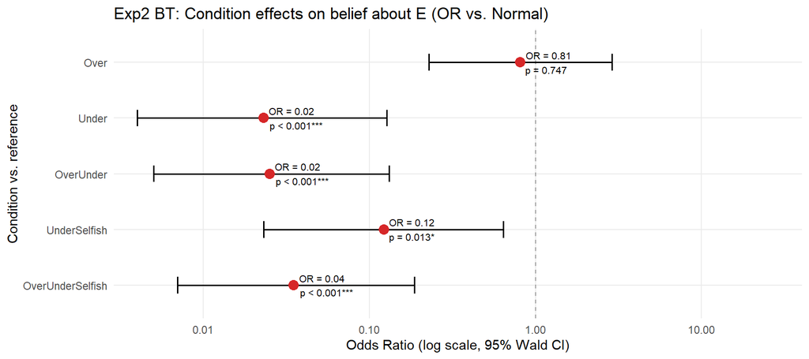

Exp2 BT: Estimated P(believed E) per condition

| Condition | prob | SE | lower.CL | upper.CL |
| --- | --- | --- | --- | --- |
| Normal | 0.995 | 0.005 | 0.967 | 0.999 |
| Over | 0.994 | 0.006 | 0.963 | 0.999 |
| Under | 0.823 | 0.112 | 0.508 | 0.954 |
| OverUnder | 0.834 | 0.118 | 0.487 | 0.964 |
| UnderSelfish | 0.961 | 0.039 | 0.766 | 0.995 |
| OverUnderSelfish | 0.875 | 0.087 | 0.595 | 0.971 |

Exp2 BT: Pairwise ORs (Bonferroni)

| contrast | OR | SE | z.ratio | df | p.value | sig |
| --- | --- | --- | --- | --- | --- | --- |
| Normal - Over | 1.233 | 0.6485927 | 0.3225064 | Inf | 1.0000 |  |
| Normal - Under | 43.235 | 0.8682719 | 4.3380973 | Inf | 0.0002 | *** |
| Normal - OverUnder | 39.998 | 0.8447806 | 4.3666119 | Inf | 0.0002 | *** |
| Normal - UnderSelfish | 8.166 | 0.8456878 | 2.4831568 | Inf | 0.1953 |  |
| Normal - OverUnderSelfish | 28.578 | 0.8563580 | 3.9149951 | Inf | 0.0014 | ** |
| Over - Under | 35.074 | 0.8383448 | 4.2434479 | Inf | 0.0003 | *** |
| Over - OverUnder | 32.448 | 0.8184659 | 4.2514345 | Inf | 0.0003 | *** |
| Over - UnderSelfish | 6.625 | 0.8280405 | 2.2834632 | Inf | 0.3360 |  |
| Over - OverUnderSelfish | 23.184 | 0.8277875 | 3.7974263 | Inf | 0.0022 | ** |
| Under - OverUnder | 0.925 | 0.8286158 | -0.0939141 | Inf | 1.0000 |  |
| Under - UnderSelfish | 0.189 | 0.8977792 | -1.8564392 | Inf | 0.9509 |  |
| Under - OverUnderSelfish | 0.661 | 0.4587254 | -0.9025237 | Inf | 1.0000 |  |
| OverUnder - UnderSelfish | 0.204 | 0.5497167 | -2.8903141 | Inf | 0.0577 | . |
| OverUnder - OverUnderSelfish | 0.714 | 0.8250008 | -0.4075049 | Inf | 1.0000 |  |
| UnderSelfish - OverUnderSelfish | 3.500 | 0.8835697 | 1.4177286 | Inf | 1.0000 |  |

## 5.4 GLMM: Condition + SVO

Exp2 BT +SVO — LRT

| Term | Chi_sq | df | p | sig |
| --- | --- | --- | --- | --- |
| Condition | 30.5911 | 5 | 0.0000 | *** |
| scale(SVO_all) | 2.2773 | 1 | 0.1313 |  |

Exp2 BT +SVO — fixed effects

| effect | term | OR | std.error | statistic | p.value | 2.5% | 97.5% | sig |
| --- | --- | --- | --- | --- | --- | --- | --- | --- |
| fixed | (Intercept) | 201.182 | 204.3410122 | 5.2222079 | 0.0000 | 27.480 | 1472.843 | *** |
| fixed | ConditionOver | 0.814 | 0.5235654 | -0.3198416 | 0.7491 | 0.231 | 2.871 |  |
| fixed | ConditionUnder | 0.022 | 0.0199218 | -4.2789312 | 0.0000 | 0.004 | 0.128 | *** |
| fixed | ConditionOverUnder | 0.026 | 0.0221092 | -4.2943020 | 0.0000 | 0.005 | 0.138 | *** |
| fixed | ConditionUnderSelfish | 0.130 | 0.1096098 | -2.4162189 | 0.0157 | 0.025 | 0.680 | * |
| fixed | ConditionOverUnderSelfish | 0.034 | 0.0296907 | -3.8734512 | 0.0001 | 0.006 | 0.188 | *** |
| fixed | scale(SVO_all) | 0.628 | 0.1935733 | -1.5090710 | 0.1313 | 0.343 | 1.149 |  |

# 6 Part 4: Cross-Experiment Comparison (Exp1 vs Exp2 DG)

> Tests whether anticipated punishment (Exp2) shifts adherence relative to no consequences (Exp1), controlling for (and interacting with) condition. The two experiments had different participants (between-subjects across experiments).

## 6.1 Additive model: Condition + Experiment

Cross-exp additive GLMM — LRT (Condition + Experiment)

| Term | Chi_sq | df | p | sig |
| --- | --- | --- | --- | --- |
| Condition | 41.9276 | 5 | 0.0000 | *** |
| Experiment | 1.5522 | 1 | 0.2128 |  |

Cross-exp additive GLMM — fixed effects (OR)

| effect | term | OR | std.error | statistic | p.value | 2.5% | 97.5% | sig |
| --- | --- | --- | --- | --- | --- | --- | --- | --- |
| fixed | (Intercept) | 1802435.889 | 3.089485e+06 | 8.403813 | 0.0000 | 62639.513 | 51864629.440 | *** |
| fixed | ConditionOver | 0.061 | 8.866690e-02 | -1.933878 | 0.0531 | 0.004 | 1.038 | . |
| fixed | ConditionUnder | 0.002 | 2.198700e-03 | -4.616466 | 0.0000 | 0.000 | 0.024 | *** |
| fixed | ConditionOverUnder | 0.001 | 7.476000e-04 | -5.464116 | 0.0000 | 0.000 | 0.008 | *** |
| fixed | ConditionUnderSelfish | 0.173 | 2.144208e-01 | -1.414748 | 0.1571 | 0.015 | 1.967 |  |
| fixed | ConditionOverUnderSelfish | 0.004 | 5.058300e-03 | -4.065168 | 0.0000 | 0.000 | 0.055 | *** |
| fixed | ExperimentExp2 DG (Ant. Pun.) | 2.424 | 1.722221e+00 | 1.245874 | 0.2128 | 0.602 | 9.757 |  |

## 6.2 Interaction model: Condition × Experiment

Cross-exp interaction GLMM — LRT (Condition × Experiment)

| Term | Chi_sq | df | p | sig |
| --- | --- | --- | --- | --- |
| Condition | 45.8301 | 5 | 0.0000 | *** |
| Experiment | 1.5374 | 1 | 0.2150 |  |
| Condition:Experiment | 17.1883 | 5 | 0.0042 | ** |

Cross-exp interaction GLMM — fixed effects (OR)

| effect | term | OR | std.error | statistic | p.value | 2.5% | 97.5% | sig |
| --- | --- | --- | --- | --- | --- | --- | --- | --- |
| fixed | (Intercept) | 9028886.106 | 1.755138e+07 | 8.2390149 | 0.0000 | 199972.947 | 4.076591e+08 | *** |
| fixed | ConditionOver | 0.168 | 2.641864e-01 | -1.1332662 | 0.2571 | 0.008 | 3.680000e+00 |  |
| fixed | ConditionUnder | 0.000 | 4.241000e-04 | -4.9537218 | 0.0000 | 0.000 | 7.000000e-03 | *** |
| fixed | ConditionOverUnder | 0.000 | 3.786000e-04 | -5.2749690 | 0.0000 | 0.000 | 5.000000e-03 | *** |
| fixed | ConditionUnderSelfish | 0.046 | 7.508430e-02 | -1.8781790 | 0.0604 | 0.002 | 1.144000e+00 | . |
| fixed | ConditionOverUnderSelfish | 0.045 | 7.080130e-02 | -1.9644662 | 0.0495 | 0.002 | 9.930000e-01 | * |
| fixed | ExperimentExp2 DG (Ant. Pun.) | 0.117 | 4.695326e-01 | -0.5356344 | 0.5922 | 0.000 | 2.977310e+02 |  |
| fixed | ConditionOver:ExperimentExp2 DG (Ant. Pun.) | 0.206 | 8.271760e-01 | -0.3934666 | 0.6940 | 0.000 | 5.389150e+02 |  |
| fixed | ConditionUnder:ExperimentExp2 DG (Ant. Pun.) | 82.871 | 3.435626e+02 | 1.0655017 | 0.2866 | 0.025 | 2.800666e+05 |  |
| fixed | ConditionOverUnder:ExperimentExp2 DG (Ant. Pun.) | 22.991 | 9.371896e+01 | 0.7690984 | 0.4418 | 0.008 | 6.781721e+04 |  |
| fixed | ConditionUnderSelfish:ExperimentExp2 DG (Ant. Pun.) | 181.362 | 7.745958e+02 | 1.2176333 | 0.2234 | 0.042 | 7.834619e+05 |  |
| fixed | ConditionOverUnderSelfish:ExperimentExp2 DG (Ant. Pun.) | 0.189 | 7.971792e-01 | -0.3946121 | 0.6931 | 0.000 | 7.485660e+02 |  |

### 6.2.1 EMM: Estimated P(chose E) per condition × experiment

Cross-exp: Estimated probabilities by condition and experiment

| Condition | Experiment | prob | SE | df | asymp.LCL | asymp.UCL |
| --- | --- | --- | --- | --- | --- | --- |
| Normal | Exp1 (Coordination) | 1.000 | 0.000 | Inf | 1.000 | 1 |
| Over | Exp1 (Coordination) | 1.000 | 0.000 | Inf | 1.000 | 1 |
| Under | Exp1 (Coordination) | 1.000 | 0.000 | Inf | 0.998 | 1 |
| OverUnder | Exp1 (Coordination) | 0.999 | 0.001 | Inf | 0.996 | 1 |
| UnderSelfish | Exp1 (Coordination) | 1.000 | 0.000 | Inf | 1.000 | 1 |
| OverUnderSelfish | Exp1 (Coordination) | 1.000 | 0.000 | Inf | 0.999 | 1 |
| Normal | Exp2 DG (Ant. Pun.) | 1.000 | 0.000 | Inf | 1.000 | 1 |
| Over | Exp2 DG (Ant. Pun.) | 1.000 | 0.000 | Inf | 1.000 | 1 |
| Under | Exp2 DG (Ant. Pun.) | 1.000 | 0.000 | Inf | 0.999 | 1 |
| OverUnder | Exp2 DG (Ant. Pun.) | 1.000 | 0.000 | Inf | 0.998 | 1 |
| UnderSelfish | Exp2 DG (Ant. Pun.) | 1.000 | 0.000 | Inf | 1.000 | 1 |
| OverUnderSelfish | Exp2 DG (Ant. Pun.) | 1.000 | 0.000 | Inf | 1.000 | 1 |

# 7 Part 4b: Three-Source Comparison (Exp1 Adherence, Exp2 Beliefs, Exp2 Punishment)

> Tests whether normative beliefs (Exp2 BT) and own behaviour under anticipated punishment (Exp2 DG) each differ from baseline no-consequences behaviour (Exp1), and whether these shifts interact with condition.

> **Source levels (reference = Exp1_Adherence):** - `Exp1_Adherence` — own choice, no consequences - `Exp2_Belief` — belief about what others will choose (Exp2 BT) - `Exp2_Punishment`— own choice under anticipated punishment (Exp2 DG)

> **Random effects:** participant ID. Exp2 participants appear in both BT and DG rows (same `E2_*` prefix); the random intercept absorbs their shared individual baseline. Exp1 participants have unique `E1_*` IDs and appear once.

## 7.1 Descriptive: observed rates per condition × source

Three-source comparison: % chose / believed E per condition

| Source | Condition | N | N_E | Pct |
| --- | --- | --- | --- | --- |
| Exp1_Adherence | Normal | 97 | 86 | 88.7 |
| Exp2_Belief | Normal | 100 | 90 | 90.0 |
| Exp2_Punishment | Normal | 101 | 97 | 96.0 |
| Exp1_Adherence | Over | 96 | 82 | 85.4 |
| Exp2_Belief | Over | 100 | 89 | 89.0 |
| Exp2_Punishment | Over | 101 | 96 | 95.0 |
| Exp1_Adherence | Under | 97 | 64 | 66.0 |
| Exp2_Belief | Under | 101 | 61 | 60.4 |
| Exp2_Punishment | Under | 101 | 83 | 82.2 |
| Exp1_Adherence | OverUnder | 97 | 62 | 63.9 |
| Exp2_Belief | OverUnder | 101 | 60 | 59.4 |
| Exp2_Punishment | OverUnder | 100 | 77 | 77.0 |
| Exp1_Adherence | UnderSelfish | 97 | 82 | 84.5 |
| Exp2_Belief | UnderSelfish | 101 | 74 | 73.3 |
| Exp2_Punishment | UnderSelfish | 100 | 91 | 91.0 |
| Exp1_Adherence | OverUnderSelfish | 96 | 76 | 79.2 |
| Exp2_Belief | OverUnderSelfish | 101 | 65 | 64.4 |
| Exp2_Punishment | OverUnderSelfish | 101 | 80 | 79.2 |

## 7.2 Additive model: Condition + Source

Three-source additive GLMM — LRT (Condition + Source)

| Term | Chi_sq | df | p | sig |
| --- | --- | --- | --- | --- |
| Condition | 85.8993 | 5 | 0 | *** |
| Source | 61.3449 | 2 | 0 | *** |

Three-source additive GLMM — fixed effects (OR vs. Exp1_Adherence / Normal)

| effect | term | OR | std.error | statistic | p.value | 2.5% | 97.5% | sig |
| --- | --- | --- | --- | --- | --- | --- | --- | --- |
| fixed | (Intercept) | 23205.430 | 2.352724e+04 | 9.9146473 | 0.0000 | 3181.147 | 169276.025 | *** |
| fixed | ConditionOver | 0.627 | 3.156386e-01 | -0.9272445 | 0.3538 | 0.234 | 1.682 |  |
| fixed | ConditionUnder | 0.014 | 8.616200e-03 | -7.0208665 | 0.0000 | 0.004 | 0.047 | *** |
| fixed | ConditionOverUnder | 0.008 | 4.476800e-03 | -8.2649822 | 0.0000 | 0.002 | 0.024 | *** |
| fixed | ConditionUnderSelfish | 0.079 | 4.202740e-02 | -4.7777876 | 0.0000 | 0.028 | 0.224 | *** |
| fixed | ConditionOverUnderSelfish | 0.023 | 1.379620e-02 | -6.3530297 | 0.0000 | 0.007 | 0.074 | *** |
| fixed | SourceExp2_Belief | 0.529 | 2.910805e-01 | -1.1566592 | 0.2474 | 0.180 | 1.555 |  |
| fixed | SourceExp2_Punishment | 6.686 | 4.003117e+00 | 3.1736397 | 0.0015 | 2.068 | 21.617 | ** |

## 7.3 Interaction model: Condition × Source

Three-source interaction GLMM — LRT (Condition × Source)

| Term | Chi_sq | df | p | sig |
| --- | --- | --- | --- | --- |
| Condition | 82.5145 | 5 | 0.0000 | *** |
| Source | 58.3940 | 2 | 0.0000 | *** |
| Condition:Source | 14.1886 | 10 | 0.1646 |  |

Three-source interaction GLMM — fixed effects (OR)

| effect | term | OR | std.error | statistic | p.value | 2.5% | 97.5% | sig |
| --- | --- | --- | --- | --- | --- | --- | --- | --- |
| fixed | (Intercept) | 25883.131 | 3.861329e+04 | 6.8113198 | 0.0000 | 1390.487 | 481799.958 | *** |
| fixed | ConditionOver | 0.309 | 4.023226e-01 | -0.9018132 | 0.3672 | 0.024 | 3.973 |  |
| fixed | ConditionUnder | 0.010 | 1.284990e-02 | -3.6206883 | 0.0003 | 0.001 | 0.122 | *** |
| fixed | ConditionOverUnder | 0.007 | 9.149600e-03 | -3.9946378 | 0.0001 | 0.001 | 0.083 | *** |
| fixed | ConditionUnderSelfish | 0.121 | 1.478917e-01 | -1.7275072 | 0.0841 | 0.011 | 1.329 | . |
| fixed | ConditionOverUnderSelfish | 0.116 | 1.422348e-01 | -1.7553662 | 0.0792 | 0.010 | 1.286 | . |
| fixed | SourceExp2_Belief | 0.430 | 6.080034e-01 | -0.5970023 | 0.5505 | 0.027 | 6.884 |  |
| fixed | SourceExp2_Punishment | 24.575 | 3.838418e+01 | 2.0499199 | 0.0404 | 1.151 | 524.789 | * |
| fixed | ConditionOver:SourceExp2_Belief | 2.562 | 3.771459e+00 | 0.6388903 | 0.5229 | 0.143 | 45.892 |  |
| fixed | ConditionUnder:SourceExp2_Belief | 1.805 | 3.055350e+00 | 0.3489535 | 0.7271 | 0.065 | 49.802 |  |
| fixed | ConditionOverUnder:SourceExp2_Belief | 2.921 | 4.707803e+00 | 0.6652894 | 0.5059 | 0.124 | 68.750 |  |
| fixed | ConditionUnderSelfish:SourceExp2_Belief | 1.208 | 2.036758e+00 | 0.1123596 | 0.9105 | 0.044 | 32.873 |  |
| fixed | ConditionOverUnderSelfish:SourceExp2_Belief | 0.271 | 4.550224e-01 | -0.7777370 | 0.4367 | 0.010 | 7.269 |  |
| fixed | ConditionOver:SourceExp2_Punishment | 1.762 | 3.029674e+00 | 0.3296058 | 0.7417 | 0.061 | 51.217 |  |
| fixed | ConditionUnder:SourceExp2_Punishment | 1.043 | 1.889778e+00 | 0.0235021 | 0.9812 | 0.030 | 36.311 |  |
| fixed | ConditionOverUnder:SourceExp2_Punishment | 0.171 | 2.932840e-01 | -1.0303396 | 0.3029 | 0.006 | 4.915 |  |
| fixed | ConditionUnderSelfish:SourceExp2_Punishment | 0.185 | 3.458026e-01 | -0.9026661 | 0.3667 | 0.005 | 7.219 |  |
| fixed | ConditionOverUnderSelfish:SourceExp2_Punishment | 0.055 | 1.016594e-01 | -1.5766913 | 0.1149 | 0.002 | 2.020 |  |

## 7.4 Estimated probabilities per condition × source

Three-source: Estimated P(chose/believed E) per condition × source

| Condition | Source | prob | SE | df | asymp.LCL | asymp.UCL |
| --- | --- | --- | --- | --- | --- | --- |
| Normal | Exp1_Adherence | 1.000 | 0.000 | Inf | 1.000 | 1.000 |
| Over | Exp1_Adherence | 1.000 | 0.000 | Inf | 1.000 | 1.000 |
| Under | Exp1_Adherence | 0.997 | 0.002 | Inf | 0.989 | 0.999 |
| OverUnder | Exp1_Adherence | 0.994 | 0.004 | Inf | 0.979 | 0.998 |
| UnderSelfish | Exp1_Adherence | 0.999 | 0.000 | Inf | 0.997 | 1.000 |
| OverUnderSelfish | Exp1_Adherence | 0.998 | 0.001 | Inf | 0.993 | 1.000 |
| Normal | Exp2_Belief | 1.000 | 0.000 | Inf | 0.999 | 1.000 |
| Over | Exp2_Belief | 1.000 | 0.000 | Inf | 0.999 | 1.000 |
| Under | Exp2_Belief | 0.994 | 0.004 | Inf | 0.974 | 0.999 |
| OverUnder | Exp2_Belief | 0.989 | 0.008 | Inf | 0.956 | 0.997 |
| UnderSelfish | Exp2_Belief | 0.999 | 0.001 | Inf | 0.994 | 1.000 |
| OverUnderSelfish | Exp2_Belief | 0.997 | 0.003 | Inf | 0.983 | 0.999 |
| Normal | Exp2_Punishment | 1.000 | 0.000 | Inf | 1.000 | 1.000 |
| Over | Exp2_Punishment | 1.000 | 0.000 | Inf | 1.000 | 1.000 |
| Under | Exp2_Punishment | 1.000 | 0.000 | Inf | 0.997 | 1.000 |
| OverUnder | Exp2_Punishment | 0.999 | 0.001 | Inf | 0.995 | 1.000 |
| UnderSelfish | Exp2_Punishment | 1.000 | 0.000 | Inf | 0.999 | 1.000 |
| OverUnderSelfish | Exp2_Punishment | 1.000 | 0.000 | Inf | 0.998 | 1.000 |

## 7.5 Source contrasts (averaged over conditions)

Three-source: Pairwise OR contrasts between sources (Bonferroni, averaged over conditions)

| contrast | odds.ratio | SE | df | null | z.ratio | p.value |
| --- | --- | --- | --- | --- | --- | --- |
| Exp1_Adherence / Exp2_Belief | 1.889 | 1.038 | Inf | 1 | 1.157 | 0.742 |
| Exp1_Adherence / Exp2_Punishment | 0.150 | 0.090 | Inf | 1 | -3.174 | 0.005 |
| Exp2_Belief / Exp2_Punishment | 0.079 | 0.026 | Inf | 1 | -7.832 | 0.000 |

# 8 Part 5: Experiment 3 — Option-Level Tests

> **Design:** Between-subjects for conditions (each participant saw one condition; N ≈ 144–147 per condition). Within-subjects for options A–I (each participant rated all 9 options within their assigned condition). **DVs:** 6-point Likert compliance judgment + deduction points (0–50).

## 8.1 5.1 Deduction Points — Friedman Test + Pairwise vs Option E

### 8.1.1 Normal

**Friedman test:** Friedman χ²(8, N = 144) = 349.368, p < 0.0001 | Kendall’s W = 0.303

**Pairwise Wilcoxon vs Option E (Bonferroni-corrected):**

Normal: deduction pairwise vs E

|  | Option | Reference | N_pairs | W_stat | p_raw | r_rb | p_adj | sig |
| --- | --- | --- | --- | --- | --- | --- | --- | --- |
| V…1 | A-100-0 | E-50-50 | 144 | 4437.0 | 0.0000 | 0.906 | 0.0000 | *** |
| V…2 | B-90-10 | E-50-50 | 144 | 4908.5 | 0.0000 | 0.944 | 0.0000 | *** |
| V…3 | C-80-20 | E-50-50 | 144 | 4384.0 | 0.0000 | 0.883 | 0.0000 | *** |
| V…4 | D-70-30 | E-50-50 | 144 | 4291.0 | 0.0000 | 0.882 | 0.0000 | *** |
| V…5 | F-30-70 | E-50-50 | 144 | 1309.5 | 0.0000 | 0.641 | 0.0000 | *** |
| V…6 | G-20-80 | E-50-50 | 144 | 1219.0 | 0.0002 | 0.583 | 0.0016 | ** |
| V…7 | H-10-90 | E-50-50 | 144 | 1293.5 | 0.0007 | 0.512 | 0.0056 | ** |
| V…8 | I-0-100 | E-50-50 | 144 | 1038.0 | 0.0014 | 0.507 | 0.0112 | * |

### 8.1.2 Over

**Friedman test:** Friedman χ²(8, N = 144) = 271.219, p < 0.0001 | Kendall’s W = 0.235

**Pairwise Wilcoxon vs Option E (Bonferroni-corrected):**

Over: deduction pairwise vs E

|  | Option | Reference | N_pairs | W_stat | p_raw | r_rb | p_adj | sig |
| --- | --- | --- | --- | --- | --- | --- | --- | --- |
| V…1 | A-100-0 | E-50-50 | 144 | 3956.0 | 0.0000 | 0.810 | 0.0000 | *** |
| V…2 | B-90-10 | E-50-50 | 144 | 4021.0 | 0.0000 | 0.801 | 0.0000 | *** |
| V…3 | C-50-50 | E-50-50 | 144 | 166.5 | 0.1989 | 0.316 | 1.0000 |  |
| V…4 | D-70-30 | E-50-50 | 144 | 3715.0 | 0.0000 | 0.814 | 0.0000 | *** |
| V…5 | F-30-70 | E-50-50 | 144 | 1182.0 | 0.0000 | 0.652 | 0.0000 | *** |
| V…6 | G-20-80 | E-50-50 | 144 | 1023.5 | 0.0002 | 0.605 | 0.0016 | ** |
| V…7 | H-10-90 | E-50-50 | 144 | 1171.5 | 0.0001 | 0.637 | 0.0008 | *** |
| V…8 | I-0-100 | E-50-50 | 144 | 775.0 | 0.0002 | 0.638 | 0.0016 | ** |

### 8.1.3 Under

**Friedman test:** Friedman χ²(8, N = 147) = 226.849, p < 0.0001 | Kendall’s W = 0.193

**Pairwise Wilcoxon vs Option E (Bonferroni-corrected):**

Under: deduction pairwise vs E

|  | Option | Reference | N_pairs | W_stat | p_raw | r_rb | p_adj | sig |
| --- | --- | --- | --- | --- | --- | --- | --- | --- |
| V…1 | A-100-0 | E-30-70 | 147 | 4242.0 | 0.0000 | 0.680 | 0.0000 | *** |
| V…2 | B-90-10 | E-30-70 | 147 | 3875.5 | 0.0000 | 0.665 | 0.0000 | *** |
| V…3 | C-80-20 | E-30-70 | 147 | 3235.0 | 0.0000 | 0.580 | 0.0000 | *** |
| V…4 | D-60-40 | E-30-70 | 147 | 2888.5 | 0.0007 | 0.411 | 0.0056 | ** |
| V…5 | F-70-30 | E-30-70 | 147 | 2000.0 | 0.0000 | 0.565 | 0.0000 | *** |
| V…6 | G-20-80 | E-30-70 | 147 | 875.0 | 0.0214 | 0.373 | 0.1712 |  |
| V…7 | H-10-90 | E-30-70 | 147 | 961.0 | 0.0601 | 0.294 | 0.4808 |  |
| V…8 | I-0-100 | E-30-70 | 147 | 800.5 | 0.1159 | 0.256 | 0.9272 |  |

### 8.1.4 OverUnder

**Friedman test:** Friedman χ²(8, N = 146) = 233.383, p < 0.0001 | Kendall’s W = 0.200

**Pairwise Wilcoxon vs Option E (Bonferroni-corrected):**

OverUnder: deduction pairwise vs E

|  | Option | Reference | N_pairs | W_stat | p_raw | r_rb | p_adj | sig |
| --- | --- | --- | --- | --- | --- | --- | --- | --- |
| V…1 | A-100-0 | E-30-70 | 146 | 4087.0 | 0.0000 | 0.685 | 0.0000 | *** |
| V…2 | B-90-10 | E-30-70 | 146 | 3948.5 | 0.0000 | 0.696 | 0.0000 | *** |
| V…3 | C-50-50 | E-30-70 | 146 | 684.5 | 0.6196 | -0.078 | 1.0000 |  |
| V…4 | D-80-20 | E-30-70 | 146 | 3538.0 | 0.0000 | 0.690 | 0.0000 | *** |
| V…5 | F-70-30 | E-30-70 | 146 | 2514.5 | 0.0000 | 0.675 | 0.0000 | *** |
| V…6 | G-20-80 | E-30-70 | 146 | 693.5 | 0.0464 | 0.340 | 0.3712 |  |
| V…7 | H-10-90 | E-30-70 | 146 | 699.5 | 0.3884 | 0.142 | 1.0000 |  |
| V…8 | I-0-100 | E-30-70 | 146 | 669.5 | 0.7607 | 0.050 | 1.0000 |  |

### 8.1.5 UnderSelfish

**Friedman test:** Friedman χ²(8, N = 144) = 158.231, p < 0.0001 | Kendall’s W = 0.137

**Pairwise Wilcoxon vs Option E (Bonferroni-corrected):**

UnderSelfish: deduction pairwise vs E

|  | Option | Reference | N_pairs | W_stat | p_raw | r_rb | p_adj | sig |
| --- | --- | --- | --- | --- | --- | --- | --- | --- |
| V…1 | A-70-30 | E-100-0 | 144 | 1319.5 | 0.0051 | -0.341 | 0.0408 | * |
| V…2 | B-90-10 | E-100-0 | 144 | 1601.5 | 0.4122 | -0.103 | 1.0000 |  |
| V…3 | C-80-20 | E-100-0 | 144 | 1456.0 | 0.0519 | -0.239 | 0.4152 |  |
| V…4 | D-60-40 | E-100-0 | 144 | 1096.5 | 0.0001 | -0.476 | 0.0008 | *** |
| V…5 | F-30-70 | E-100-0 | 144 | 901.5 | 0.0000 | -0.518 | 0.0000 | *** |
| V…6 | G-20-80 | E-100-0 | 144 | 1086.0 | 0.0003 | -0.445 | 0.0024 | ** |
| V…7 | H-10-90 | E-100-0 | 144 | 982.5 | 0.0001 | -0.475 | 0.0008 | *** |
| V…8 | I-0-100 | E-100-0 | 144 | 819.5 | 0.0003 | -0.468 | 0.0024 | ** |

### 8.1.6 OverUnderSelfish

**Friedman test:** Friedman χ²(8, N = 145) = 236.956, p < 0.0001 | Kendall’s W = 0.204

**Pairwise Wilcoxon vs Option E (Bonferroni-corrected):**

OverUnderSelfish: deduction pairwise vs E

|  | Option | Reference | N_pairs | W_stat | p_raw | r_rb | p_adj | sig |
| --- | --- | --- | --- | --- | --- | --- | --- | --- |
| V…1 | A-70-30 | E-100-0 | 145 | 1421.5 | 0.0001 | -0.437 | 0.0008 | *** |
| V…2 | B-90-10 | E-100-0 | 145 | 1783.0 | 0.0874 | -0.201 | 0.6992 |  |
| V…3 | C-50-50 | E-100-0 | 145 | 729.5 | 0.0000 | -0.666 | 0.0000 | *** |
| V…4 | D-80-20 | E-100-0 | 145 | 1796.0 | 0.0251 | -0.260 | 0.2008 |  |
| V…5 | F-30-70 | E-100-0 | 145 | 973.0 | 0.0000 | -0.615 | 0.0000 | *** |
| V…6 | G-20-80 | E-100-0 | 145 | 955.0 | 0.0000 | -0.598 | 0.0000 | *** |
| V…7 | H-10-90 | E-100-0 | 145 | 961.5 | 0.0000 | -0.578 | 0.0000 | *** |
| V…8 | I-0-100 | E-100-0 | 145 | 910.0 | 0.0000 | -0.525 | 0.0000 | *** |

## 8.2 5.2 Likert Compliance — Friedman Test + Pairwise vs Option E

### 8.2.1 Normal

**Friedman test:** Friedman χ²(8, N = 144) = 440.609, p < 0.0001 | Kendall’s W = 0.382

**Pairwise Wilcoxon vs Option E (Bonferroni-corrected):**

Normal: Likert pairwise vs E

|  | Option | Reference | N_pairs | W_stat | p_raw | r_rb | p_adj | sig |
| --- | --- | --- | --- | --- | --- | --- | --- | --- |
| V…1 | A-100-0 | E-50-50 | 144 | 200.0 | 0 | -0.955 | 0 | *** |
| V…2 | B-90-10 | E-50-50 | 144 | 191.0 | 0 | -0.959 | 0 | *** |
| V…3 | C-80-20 | E-50-50 | 144 | 205.0 | 0 | -0.955 | 0 | *** |
| V…4 | D-70-30 | E-50-50 | 144 | 312.5 | 0 | -0.932 | 0 | *** |
| V…5 | F-30-70 | E-50-50 | 144 | 480.0 | 0 | -0.894 | 0 | *** |
| V…6 | G-20-80 | E-50-50 | 144 | 239.0 | 0 | -0.947 | 0 | *** |
| V…7 | H-10-90 | E-50-50 | 144 | 261.5 | 0 | -0.946 | 0 | *** |
| V…8 | I-0-100 | E-50-50 | 144 | 157.0 | 0 | -0.966 | 0 | *** |

### 8.2.2 Over

**Friedman test:** Friedman χ²(8, N = 144) = 579.076, p < 0.0001 | Kendall’s W = 0.503

**Pairwise Wilcoxon vs Option E (Bonferroni-corrected):**

Over: Likert pairwise vs E

|  | Option | Reference | N_pairs | W_stat | p_raw | r_rb | p_adj | sig |
| --- | --- | --- | --- | --- | --- | --- | --- | --- |
| V…1 | A-100-0 | E-50-50 | 144 | 24.0 | 0 | -0.994 | 0 | *** |
| V…2 | B-90-10 | E-50-50 | 144 | 35.5 | 0 | -0.992 | 0 | *** |
| V…3 | C-50-50 | E-50-50 | 144 | 165.0 | 0 | -0.893 | 0 | *** |
| V…4 | D-70-30 | E-50-50 | 144 | 30.0 | 0 | -0.993 | 0 | *** |
| V…5 | F-30-70 | E-50-50 | 144 | 82.5 | 0 | -0.981 | 0 | *** |
| V…6 | G-20-80 | E-50-50 | 144 | 40.0 | 0 | -0.991 | 0 | *** |
| V…7 | H-10-90 | E-50-50 | 144 | 35.5 | 0 | -0.992 | 0 | *** |
| V…8 | I-0-100 | E-50-50 | 144 | 116.0 | 0 | -0.975 | 0 | *** |

### 8.2.3 Under

**Friedman test:** Friedman χ²(8, N = 147) = 279.833, p < 0.0001 | Kendall’s W = 0.238

**Pairwise Wilcoxon vs Option E (Bonferroni-corrected):**

Under: Likert pairwise vs E

|  | Option | Reference | N_pairs | W_stat | p_raw | r_rb | p_adj | sig |
| --- | --- | --- | --- | --- | --- | --- | --- | --- |
| V…1 | A-100-0 | E-30-70 | 147 | 981.0 | 0 | -0.747 | 0 | *** |
| V…2 | B-90-10 | E-30-70 | 147 | 836.0 | 0 | -0.788 | 0 | *** |
| V…3 | C-80-20 | E-30-70 | 147 | 766.5 | 0 | -0.785 | 0 | *** |
| V…4 | D-60-40 | E-30-70 | 147 | 1494.5 | 0 | -0.574 | 0 | *** |
| V…5 | F-70-30 | E-30-70 | 147 | 464.0 | 0 | -0.813 | 0 | *** |
| V…6 | G-20-80 | E-30-70 | 147 | 552.0 | 0 | -0.812 | 0 | *** |
| V…7 | H-10-90 | E-30-70 | 147 | 416.5 | 0 | -0.875 | 0 | *** |
| V…8 | I-0-100 | E-30-70 | 147 | 754.5 | 0 | -0.802 | 0 | *** |

### 8.2.4 OverUnder

**Friedman test:** Friedman χ²(8, N = 146) = 341.141, p < 0.0001 | Kendall’s W = 0.292

**Pairwise Wilcoxon vs Option E (Bonferroni-corrected):**

OverUnder: Likert pairwise vs E

|  | Option | Reference | N_pairs | W_stat | p_raw | r_rb | p_adj | sig |
| --- | --- | --- | --- | --- | --- | --- | --- | --- |
| V…1 | A-100-0 | E-30-70 | 146 | 455.5 | 0.000 | -0.859 | 0 | *** |
| V…2 | B-90-10 | E-30-70 | 146 | 383.5 | 0.000 | -0.877 | 0 | *** |
| V…3 | C-50-50 | E-30-70 | 146 | 4204.0 | 0.392 | -0.084 | 1 |  |
| V…4 | D-80-20 | E-30-70 | 146 | 394.5 | 0.000 | -0.863 | 0 | *** |
| V…5 | F-70-30 | E-30-70 | 146 | 281.5 | 0.000 | -0.856 | 0 | *** |
| V…6 | G-20-80 | E-30-70 | 146 | 316.0 | 0.000 | -0.884 | 0 | *** |
| V…7 | H-10-90 | E-30-70 | 146 | 289.0 | 0.000 | -0.894 | 0 | *** |
| V…8 | I-0-100 | E-30-70 | 146 | 347.5 | 0.000 | -0.884 | 0 | *** |

### 8.2.5 UnderSelfish

**Friedman test:** Friedman χ²(8, N = 144) = 190.374, p < 0.0001 | Kendall’s W = 0.165

**Pairwise Wilcoxon vs Option E (Bonferroni-corrected):**

UnderSelfish: Likert pairwise vs E

|  | Option | Reference | N_pairs | W_stat | p_raw | r_rb | p_adj | sig |
| --- | --- | --- | --- | --- | --- | --- | --- | --- |
| V…1 | A-70-30 | E-100-0 | 144 | 815.5 | 0 | -0.764 | 0 | *** |
| V…2 | B-90-10 | E-100-0 | 144 | 485.0 | 0 | -0.826 | 0 | *** |
| V…3 | C-80-20 | E-100-0 | 144 | 622.5 | 0 | -0.785 | 0 | *** |
| V…4 | D-60-40 | E-100-0 | 144 | 2104.0 | 0 | -0.466 | 0 | *** |
| V…5 | F-30-70 | E-100-0 | 144 | 1271.0 | 0 | -0.632 | 0 | *** |
| V…6 | G-20-80 | E-100-0 | 144 | 745.0 | 0 | -0.765 | 0 | *** |
| V…7 | H-10-90 | E-100-0 | 144 | 410.5 | 0 | -0.850 | 0 | *** |
| V…8 | I-0-100 | E-100-0 | 144 | 185.5 | 0 | -0.909 | 0 | *** |

### 8.2.6 OverUnderSelfish

**Friedman test:** Friedman χ²(8, N = 145) = 233.988, p < 0.0001 | Kendall’s W = 0.202

**Pairwise Wilcoxon vs Option E (Bonferroni-corrected):**

OverUnderSelfish: Likert pairwise vs E

|  | Option | Reference | N_pairs | W_stat | p_raw | r_rb | p_adj | sig |
| --- | --- | --- | --- | --- | --- | --- | --- | --- |
| V…1 | A-70-30 | E-100-0 | 145 | 739.5 | 0.0000 | -0.774 | 0 | *** |
| V…2 | B-90-10 | E-100-0 | 145 | 273.5 | 0.0000 | -0.894 | 0 | *** |
| V…3 | C-50-50 | E-100-0 | 145 | 4095.0 | 0.8139 | -0.023 | 1 |  |
| V…4 | D-80-20 | E-100-0 | 145 | 596.0 | 0.0000 | -0.786 | 0 | *** |
| V…5 | F-30-70 | E-100-0 | 145 | 1076.5 | 0.0000 | -0.693 | 0 | *** |
| V…6 | G-20-80 | E-100-0 | 145 | 499.5 | 0.0000 | -0.833 | 0 | *** |
| V…7 | H-10-90 | E-100-0 | 145 | 366.5 | 0.0000 | -0.871 | 0 | *** |
| V…8 | I-0-100 | E-100-0 | 145 | 137.5 | 0.0000 | -0.940 | 0 | *** |

## 8.3 5.3 Deduction Points — Linear Mixed Model (all conditions)

> `value ~ Condition * ChoiceLabel + (1|participant_id)` Tests whether condition moderates which options receive higher deduction points.

Exp3 LMM — LRT for fixed effects

| Term | Chi_sq | df | p | sig |
| --- | --- | --- | --- | --- |
| Condition | 5.0432 | 5 | 0.4106 |  |
| ChoiceLabel | 1378.6883 | 15 | 0.0000 | *** |
| Condition:ChoiceLabel | 24.8538 | 33 | 0.8451 |  |

Exp3 LMM — first 20 fixed effects (estimate, 95% CI)

| effect | term | estimate | std.error | statistic | 2.5% | 97.5% | p.value | sig |
| --- | --- | --- | --- | --- | --- | --- | --- | --- |
| fixed | (Intercept) | 23.746 | 1.221871 | 19.4343514 | 21.351 | 26.141 | 0.0000 | *** |
| fixed | ConditionOver | -1.566 | 1.446710 | -1.0821373 | -4.401 | 1.270 | 0.2792 |  |
| fixed | ConditionUnder | -2.587 | 1.440649 | -1.7956194 | -5.410 | 0.237 | 0.0726 | . |
| fixed | ConditionOverUnder | -3.033 | 1.440829 | -2.1049792 | -5.857 | -0.209 | 0.0353 | * |
| fixed | ConditionUnderSelfish | 1.017 | 1.449496 | 0.7016046 | -1.824 | 3.858 | 0.4829 |  |
| fixed | ConditionOverUnderSelfish | -0.507 | 1.443463 | -0.3510943 | -3.336 | 2.322 | 0.7255 |  |
| fixed | ChoiceLabelA-70-30 | -9.943 | 2.016438 | -4.9308813 | -13.895 | -5.991 | 0.0000 | *** |
| fixed | ChoiceLabelB-90-10 | -3.056 | 1.428302 | -2.1392929 | -5.855 | -0.256 | 0.0324 | * |
| fixed | ChoiceLabelC-50-50 | -17.584 | 2.016438 | -8.7204247 | -21.536 | -13.632 | 0.0000 | *** |
| fixed | ChoiceLabelC-80-20 | -6.910 | 1.428302 | -4.8377191 | -9.709 | -4.110 | 0.0000 | *** |
| fixed | ChoiceLabelD-60-40 | -13.736 | 2.019924 | -6.8003123 | -17.695 | -9.777 | 0.0000 | *** |
| fixed | ChoiceLabelD-70-30 | -9.069 | 1.428302 | -6.3498102 | -11.869 | -6.270 | 0.0000 | *** |
| fixed | ChoiceLabelD-80-20 | -5.915 | 2.016438 | -2.9335045 | -9.867 | -1.963 | 0.0034 | ** |
| fixed | ChoiceLabelE-100-0 | -3.536 | 2.016438 | -1.7535474 | -7.488 | 0.416 | 0.0795 | . |
| fixed | ChoiceLabelE-30-70 | -13.144 | 1.418485 | -9.2661080 | -15.924 | -10.364 | 0.0000 | *** |
| fixed | ChoiceLabelE-50-50 | -20.201 | 1.428302 | -14.1436430 | -23.001 | -17.402 | 0.0000 | *** |
| fixed | ChoiceLabelF-30-70 | -15.674 | 1.428302 | -10.9736000 | -18.473 | -12.874 | 0.0000 | *** |
| fixed | ChoiceLabelF-70-30 | -7.616 | 1.418485 | -5.3694175 | -10.397 | -4.836 | 0.0000 | *** |
| fixed | ChoiceLabelG-20-80 | -15.563 | 1.428302 | -10.8958075 | -18.362 | -12.763 | 0.0000 | *** |
| fixed | ChoiceLabelH-10-90 | -15.257 | 1.428302 | -10.6818782 | -18.056 | -12.458 | 0.0000 | *** |

Exp3 LMM — ICC and R²

| ICC | R2_marginal.Marginal R2 | R2_conditional.Conditional R2 |
| --- | --- | --- |
| 0.429 | 0.088 | 0.517 |

# 9 Part 6: Role-Based Analysis

## 9.1 6.0 Rationale and Coding Scheme

> Standard condition-level analyses (Parts 1–5) treat the six conditions as nominal categories. Role coding replaces this with a theoretically motivated taxonomy that directly operationalises the text-vs-purpose distinction.

> **The six mutually exclusive option roles:**

> | Role | Option E? | 50-50? | 100-0? | Conditions |
> | --- | --- | --- | --- | --- |
> | `Textual_Equal` | ✓ | ✓ |  | Normal, Over |
> | `Textual_Pure` | ✓ |  |  | Under, OverUnder |
> | `Textual_Selfish` | ✓ |  | ✓ | UnderSelfish, OverUnderSelfish |
> | `Equal_Only` |  | ✓ |  | Over (C), OverUnder (C), OverUnderSelfish (C) |
> | `Selfish_Only` |  |  | ✓ | Normal–OverUnder (A) |
> | `Other` |  |  |  | All (reference) |

> **For Exp1/Exp2 (binary choice):** The role of option E in each participant’s condition — called `E_Role` — reduces six conditions to three levels (Textual_Equal, Textual_Pure, Textual_Selfish). This tests whether compliance tracks the theoretical category rather than the specific condition label.

> **For Exp3 (option ratings):** Each option A–I within each condition is assigned a Role. A within-participant LMM — `Rating ~ Role + Condition + (1|participant)` — tests whether certain option properties (textual, purposive, selfish) systematically drive compliance judgments and punishment severity.

> **Key theoretical contrasts:** - `Textual_Pure` vs. `Equal_Only`: does following the letter buy more leniency than achieving the purpose? (Within OverUnder: E=30-70 vs. C=50-50) - `Textual_Selfish` vs. `Selfish_Only`: does the textual label reduce punishment for the greedy option? (Cross-condition: UnderSelfish/OverUnderSelfish vs. Normal–OverUnder) - `Textual_Equal` vs. `Equal_Only`: does the textual label add leniency on top of purpose-achievement? (Within Over: E=50-50 vs. C=50-50)

Role coding: non-Other options per condition (Other = all remaining options)

| Condition | Option | Payoff | Role |
| --- | --- | --- | --- |
| Normal | A | 100-0 | Selfish_Only |
| Normal | E | 50-50 | Textual_Equal |
| Over | A | 100-0 | Selfish_Only |
| Over | C | 50-50 | Equal_Only |
| Over | E | 50-50 | Textual_Equal |
| Under | A | 100-0 | Selfish_Only |
| Under | E | 30-70 | Textual_Pure |
| OverUnder | A | 100-0 | Selfish_Only |
| OverUnder | C | 50-50 | Equal_Only |
| OverUnder | E | 30-70 | Textual_Pure |
| UnderSelfish | E | 100-0 | Textual_Selfish |
| OverUnderSelfish | C | 50-50 | Equal_Only |
| OverUnderSelfish | E | 100-0 | Textual_Selfish |

## 9.2 6.1 Exp1 — Adherence by E_Role

> Collapses Normal & Over → Textual_Equal; Under & OverUnder → Textual_Pure; UnderSelfish & OverUnderSelfish → Textual_Selfish. Tests whether compliance is driven by the Role of E rather than specific conditions.

Exp1: adherence by E_Role

| E_Role | N | N_E | Pct |
| --- | --- | --- | --- |
| Textual_Equal | 193 | 168 | 87.0 |
| Textual_Pure | 194 | 126 | 64.9 |
| Textual_Selfish | 193 | 158 | 81.9 |

Exp1 E_Role GLMM — LRT

| Term | Chi_sq | df | p | sig |
| --- | --- | --- | --- | --- |
| E_Role | 40.9867 | 2 | 0 | *** |

Exp1 E_Role GLMM — fixed effects (OR vs. Textual_Equal)

| effect | term | OR | std.error | statistic | p.value | 2.5% | 97.5% | sig |
| --- | --- | --- | --- | --- | --- | --- | --- | --- |
| fixed | (Intercept) | 32935051.060 | 6.514701e+07 | 8.751089 | 0.000 | 682249.689 | 1.589913e+09 | *** |
| fixed | E_RoleTextual_Pure | 0.000 | 2.252000e-04 | -6.359209 | 0.000 | 0.000 | 2.000000e-03 | *** |
| fixed | E_RoleTextual_Selfish | 0.135 | 1.366248e-01 | -1.977330 | 0.048 | 0.018 | 9.830000e-01 | * |

Exp1: estimated P(chose E) by E_Role

| E_Role | prob | SE | df | asymp.LCL | asymp.UCL |
| --- | --- | --- | --- | --- | --- |
| Textual_Equal | 1 | 0 | Inf | 1.000 | 1 |
| Textual_Pure | 1 | 0 | Inf | 0.999 | 1 |
| Textual_Selfish | 1 | 0 | Inf | 1.000 | 1 |

## 9.3 6.2 Exp2 DG — Anticipated Punishment by E_Role

Exp2 DG: adherence by E_Role

| E_Role | N | N_E | Pct |
| --- | --- | --- | --- |
| Textual_Equal | 202 | 193 | 95.5 |
| Textual_Pure | 201 | 160 | 79.6 |
| Textual_Selfish | 201 | 171 | 85.1 |

Exp2 DG E_Role GLMM — LRT

| Term | Chi_sq | df | p | sig |
| --- | --- | --- | --- | --- |
| E_Role | 9.0147 | 2 | 0.011 | * |

Exp2 DG E_Role GLMM — fixed effects (OR vs. Textual_Equal)

| effect | term | OR | std.error | statistic | p.value | 2.5% | 97.5% | sig |
| --- | --- | --- | --- | --- | --- | --- | --- | --- |
| fixed | (Intercept) | 10058.575 | 1.277747e+04 | 7.2550842 | 0.0000 | 834.160 | 121289.534 | *** |
| fixed | E_RoleTextual_Pure | 0.103 | 1.241746e-01 | -1.8811732 | 0.0599 | 0.010 | 1.100 | . |
| fixed | E_RoleTextual_Selfish | 0.410 | 5.261638e-01 | -0.6947087 | 0.4872 | 0.033 | 5.067 |  |

## 9.4 6.3 Exp2 BT — Normative Beliefs by E_Role

Exp2 BT: beliefs by E_Role

| E_Role | N | N_E | Pct |
| --- | --- | --- | --- |
| Textual_Equal | 200 | 179 | 89.5 |
| Textual_Pure | 202 | 121 | 59.9 |
| Textual_Selfish | 202 | 139 | 68.8 |

Exp2 BT E_Role GLMM — LRT

| Term | Chi_sq | df | p | sig |
| --- | --- | --- | --- | --- |
| E_Role | 31.3328 | 2 | 0 | *** |

Exp2 BT E_Role GLMM — fixed effects (OR vs. Textual_Equal)

| effect | term | OR | std.error | statistic | p.value | 2.5% | 97.5% | sig |
| --- | --- | --- | --- | --- | --- | --- | --- | --- |
| fixed | (Intercept) | 150.033 | 123.5353116 | 6.085651 | 0 | 29.876 | 753.452 | *** |
| fixed | E_RoleTextual_Pure | 0.028 | 0.0183299 | -5.523871 | 0 | 0.008 | 0.101 | *** |
| fixed | E_RoleTextual_Selfish | 0.073 | 0.0449428 | -4.234810 | 0 | 0.022 | 0.244 | *** |

## 9.5 6.4 Three-Source Comparison by E_Role

> Replaces the six-condition factor with E_Role (3 levels) in the three-source model. Tests whether the Source effect (Exp1 / BT / DG) interacts with the type of textual prescription.

Three-source: % chose/believed E by E_Role × Source

| E_Role | Source | N | Pct |
| --- | --- | --- | --- |
| Textual_Equal | Exp1_Adherence | 193 | 87.0 |
| Textual_Equal | Exp2_Belief | 200 | 89.5 |
| Textual_Equal | Exp2_Punishment | 202 | 95.5 |
| Textual_Pure | Exp1_Adherence | 194 | 64.9 |
| Textual_Pure | Exp2_Belief | 202 | 59.9 |
| Textual_Pure | Exp2_Punishment | 201 | 79.6 |
| Textual_Selfish | Exp1_Adherence | 193 | 81.9 |
| Textual_Selfish | Exp2_Belief | 202 | 68.8 |
| Textual_Selfish | Exp2_Punishment | 201 | 85.1 |

Three-source E_Role additive GLMM — LRT

| Term | Chi_sq | df | p | sig |
| --- | --- | --- | --- | --- |
| E_Role | 81.1881 | 2 | 0 | *** |
| Source | 60.5191 | 2 | 0 | *** |

Three-source E_Role additive — fixed effects (OR)

| effect | term | OR | std.error | statistic | p.value | 2.5% | 97.5% | sig |
| --- | --- | --- | --- | --- | --- | --- | --- | --- |
| fixed | (Intercept) | 12328.876 | 1.177050e+04 | 9.866556 | 0.0000 | 1897.898 | 80089.218 | *** |
| fixed | E_RoleTextual_Pure | 0.016 | 7.355800e-03 | -8.932033 | 0.0000 | 0.006 | 0.039 | *** |
| fixed | E_RoleTextual_Selfish | 0.059 | 2.465010e-02 | -6.768907 | 0.0000 | 0.026 | 0.134 | *** |
| fixed | SourceExp2_Belief | 0.493 | 2.646470e-01 | -1.317221 | 0.1878 | 0.172 | 1.412 |  |
| fixed | SourceExp2_Punishment | 5.589 | 3.266667e+00 | 2.944061 | 0.0032 | 1.777 | 17.573 | ** |

Three-source E_Role interaction GLMM — LRT

| Term | Chi_sq | df | p | sig |
| --- | --- | --- | --- | --- |
| E_Role | 78.3842 | 2 | 0.0000 | *** |
| Source | 57.3163 | 2 | 0.0000 | *** |
| E_Role:Source | 9.9495 | 4 | 0.0413 | * |

Three-source E_Role interaction — fixed effects (OR)

| effect | term | OR | std.error | statistic | p.value | 2.5% | 97.5% | sig |
| --- | --- | --- | --- | --- | --- | --- | --- | --- |
| fixed | (Intercept) | 7977.309 | 9738.4950267 | 7.3595548 | 0.0000 | 729.006 | 87293.419 | *** |
| fixed | E_RoleTextual_Pure | 0.022 | 0.0182066 | -4.5367149 | 0.0000 | 0.004 | 0.113 | *** |
| fixed | E_RoleTextual_Selfish | 0.255 | 0.1950218 | -1.7871793 | 0.0739 | 0.057 | 1.141 | . |
| fixed | SourceExp2_Belief | 0.668 | 0.6293119 | -0.4284758 | 0.6683 | 0.105 | 4.234 |  |
| fixed | SourceExp2_Punishment | 43.173 | 46.4422267 | 3.5001376 | 0.0005 | 5.243 | 355.528 | *** |
| fixed | E_RoleTextual_Pure:SourceExp2_Belief | 1.225 | 1.2236437 | 0.2027599 | 0.8393 | 0.173 | 8.680 |  |
| fixed | E_RoleTextual_Selfish:SourceExp2_Belief | 0.331 | 0.3203372 | -1.1422781 | 0.2533 | 0.049 | 2.209 |  |
| fixed | E_RoleTextual_Pure:SourceExp2_Punishment | 0.159 | 0.1728644 | -1.6905969 | 0.0909 | 0.019 | 1.341 | . |
| fixed | E_RoleTextual_Selfish:SourceExp2_Punishment | 0.034 | 0.0390970 | -2.9665926 | 0.0030 | 0.004 | 0.319 | ** |

## 9.6 6.5 Exp3 — Compliance Judgments (Likert) by Option Role

> DV: Likert compliance score (1 = Definitely violates → 6 = Definitely complies). Model: `Likert_num ~ Role + Condition + (1|participant_id)`. Role captures within-condition differences; Condition controls for between-condition baseline.

Exp3 Likert: mean compliance score by option Role

| Role | N | Mean | SD |
| --- | --- | --- | --- |
| Other | 5944 | 2.00 | 1.42 |
| Selfish_Only | 581 | 1.60 | 1.49 |
| Equal_Only | 435 | 3.77 | 2.13 |
| Textual_Pure | 293 | 4.06 | 1.97 |
| Textual_Selfish | 289 | 3.94 | 2.31 |
| Textual_Equal | 288 | 5.53 | 1.24 |

Exp3 Likert Role LMM — ANOVA table (LRT)

|  | npar | Sum Sq | Mean Sq | F value |
| --- | --- | --- | --- | --- |
| Role | 5 | 6502.51899 | 1300.50380 | 772.463255 |
| Condition | 5 | 21.47945 | 4.29589 | 2.551639 |

Exp3 Likert Role LMM — fixed effects (vs. Other, controlling for Condition)

| term | estimate | std.error | statistic | conf.low | conf.high |
| --- | --- | --- | --- | --- | --- |
| (Intercept) | 1.958 | 0.063 | 31.327 | 1.836 | 2.081 |
| RoleSelfish_Only | -0.421 | 0.058 | -7.290 | -0.534 | -0.308 |
| RoleEqual_Only | 1.852 | 0.066 | 27.863 | 1.722 | 1.982 |
| RoleTextual_Pure | 1.994 | 0.081 | 24.660 | 1.836 | 2.153 |
| RoleTextual_Selfish | 1.982 | 0.081 | 24.446 | 1.823 | 2.141 |
| RoleTextual_Equal | 3.560 | 0.082 | 43.649 | 3.400 | 3.720 |
| ConditionOver | 0.051 | 0.057 | 0.897 | -0.060 | 0.162 |
| ConditionUnder | 0.151 | 0.058 | 2.619 | 0.038 | 0.265 |
| ConditionOverUnder | 0.015 | 0.058 | 0.268 | -0.098 | 0.129 |
| ConditionUnderSelfish | 0.067 | 0.059 | 1.136 | -0.049 | 0.182 |
| ConditionOverUnderSelfish | -0.036 | 0.058 | -0.618 | -0.150 | 0.078 |

Exp3 Likert Role LMM — ICC and R²

| ICC | R2_marginal.Marginal R2 | R2_conditional.Conditional R2 |
| --- | --- | --- |
| 0.204 | 0.264 | 0.468 |

Exp3 Likert: key Role contrasts (Bonferroni-adjusted, estimated marginal means scale)

| contrast | estimate | SE | df | z.ratio | p.value |
| --- | --- | --- | --- | --- | --- |
| Textual_Pure vs. Equal_Only | 0.142 | 0.102 | Inf | 1.398 | 0.973 |
| Textual_Pure vs. Other | 1.994 | 0.081 | Inf | 24.660 | 0.000 |
| Equal_Only vs. Other | 1.852 | 0.066 | Inf | 27.863 | 0.000 |
| Textual_Equal vs. Equal_Only | 1.708 | 0.102 | Inf | 16.715 | 0.000 |
| Textual_Selfish vs. Selfish_Only | 2.403 | 0.099 | Inf | 24.189 | 0.000 |
| Textual_Selfish vs. Other | 1.982 | 0.081 | Inf | 24.446 | 0.000 |

## 9.7 6.6 Exp3 — Deduction Points by Option Role

> DV: Deduction points assigned (0–50; higher = more punishment). Model: `value ~ Role + Condition + (1|participant_id)`.

Exp3 Deduction: mean deduction points by option Role

| Role | N | Mean | SD |
| --- | --- | --- | --- |
| Other | 5944 | 12.03 | 16.84 |
| Selfish_Only | 581 | 21.87 | 21.51 |
| Equal_Only | 435 | 5.57 | 13.28 |
| Textual_Pure | 293 | 6.60 | 13.77 |
| Textual_Selfish | 289 | 19.10 | 21.66 |
| Textual_Equal | 288 | 4.41 | 12.54 |

Exp3 Deduction Role LMM — ANOVA table (LRT)

|  | npar | Sum Sq | Mean Sq | F value |
| --- | --- | --- | --- | --- |
| Role | 5 | 114454.9561 | 22890.9912 | 143.6546702 |
| Condition | 5 | 719.9845 | 143.9969 | 0.9036667 |

Exp3 Deduction Role LMM — fixed effects (vs. Other, controlling for Condition)

| term | estimate | std.error | statistic | conf.low | conf.high |
| --- | --- | --- | --- | --- | --- |
| (Intercept) | 12.404 | 0.780 | 15.898 | 10.875 | 13.934 |
| RoleSelfish_Only | 9.955 | 0.562 | 17.721 | 8.854 | 11.056 |
| RoleEqual_Only | -6.155 | 0.647 | -9.518 | -7.422 | -4.887 |
| RoleTextual_Pure | -4.566 | 0.787 | -5.805 | -6.108 | -3.025 |
| RoleTextual_Selfish | 6.937 | 0.789 | 8.796 | 5.391 | 8.482 |
| RoleTextual_Equal | -8.278 | 0.793 | -10.434 | -9.833 | -6.723 |
| ConditionOver | -0.937 | 0.555 | -1.687 | -2.025 | 0.152 |
| ConditionUnder | -0.458 | 0.565 | -0.810 | -1.566 | 0.650 |
| ConditionOverUnder | -0.279 | 0.564 | -0.495 | -1.385 | 0.827 |
| ConditionUnderSelfish | -0.039 | 0.576 | -0.068 | -1.168 | 1.090 |
| ConditionOverUnderSelfish | -0.723 | 0.569 | -1.270 | -1.840 | 0.393 |

Exp3 Deduction Role LMM — ICC and R²

| ICC | R2_marginal.Marginal R2 | R2_conditional.Conditional R2 |
| --- | --- | --- |
| 0.428 | 0.049 | 0.476 |

Exp3 Deduction: key Role contrasts (Bonferroni-adjusted)

| contrast | estimate | SE | df | z.ratio | p.value |
| --- | --- | --- | --- | --- | --- |
| Textual_Pure vs. Equal_Only | 1.588 | 0.989 | Inf | 1.606 | 0.649 |
| Textual_Pure vs. Other | -4.566 | 0.787 | Inf | -5.805 | 0.000 |
| Equal_Only vs. Other | -6.155 | 0.647 | Inf | -9.518 | 0.000 |
| Textual_Equal vs. Equal_Only | -2.124 | 0.994 | Inf | -2.137 | 0.196 |
| Textual_Selfish vs. Selfish_Only | -3.018 | 0.966 | Inf | -3.124 | 0.011 |
| Textual_Selfish vs. Other | 6.937 | 0.789 | Inf | 8.796 | 0.000 |

## 9.8 6.7 Summary: What Role Adds Over Condition-Level Models

> **E_Role (Exp1/Exp2):** If the three E_Role GLMMs (§6.1–6.3) replicate the six-condition pattern with comparable fit, this confirms that what drives compliance is the *type* of textual prescription, not the specific condition label. The parsimony of three levels over six is a direct test of the theoretical taxonomy.

> **Option Role (Exp3):** The key contrasts in §6.5–6.6 answer the four central questions of the textualism/purposivism framework:
> 1. **Does following the letter buy leniency even when it betrays the purpose?** → `Textual_Pure` vs. `Other` (Under, OverUnder conditions)
> 2. **Does achieving the purpose buy leniency without the textual label?** → `Equal_Only` vs. `Other` (Over, OverUnder, OverUnderSelfish conditions)
> 3. **Which wins — text or purpose?** → `Textual_Pure` vs. `Equal_Only` (within OverUnder: E=30-70 vs. C=50-50, same participants, strongest within-person test)
> 4. **Does the textual label soften punishment for greed?** → `Textual_Selfish` vs. `Selfish_Only` (cross-condition: E=100-0 in UnderSelfish/OverUnderSelfish vs. A=100-0 in Normal–OverUnder)